# Data mining Group Project

Group Name: Venturers-Group 3 Members: Sixuan Tian, Yi Chen Huang, Ruixin Huang, Anita Nelliat AndrewId: sixuant, yichenhu, ruixinh, anelliat

# Project on Customer Analysis for an Online Greeting Card Company

## Problem Statement

Our client is an online greeting card company. The company offers monthly subscriptions at a rate of $1 per month for access to their eCard website. The client is interested in understanding the life-time value (ltv) of their customers. The life-time value of a customer is defined as the total revenue earned by the company over the course of their relationship with the customer. The `ltv Dataset.xlsx` dataset represents usage statistics for 10,000 customers. Usage is summarized at a daily level and covers a period of 4 years from 2011-01-01 to 2014-12-31. The following is a description of each field captured in the enclosed data set containing a total of 10,000 customers.

| Data Field | Description |
| --- | --- |
| `id` | A unique user identifier |
| `status` | Subscription status ‘0’- new, ‘1’- open, ‘2’- cancelation event |
| `gender` | User gender ‘M’- male, ‘F’- female |
| `date` | Date of in which user ‘id’ logged into the site |
| `pages` | Number of pages visted by user ‘id’ on date ‘date’ |
| `onsite` | Number of minutes spent on site by user ‘id’ on date ‘date’ |
| `entered` | Flag indicating whether or not user entered the send order path on date ‘date’ |
| `completed` | Flag indicating whether the user completed the order (sent an eCard) |
| `holiday` | Flag indicating whether at least one completed order included a holiday themed card |
| ———— | ————————————————————————————- |

- Key tasks
  - Develop an attrition model, to predict whether a customer will cancel their subscription in the near future. Characterize your model performance.
  - Develop a model for estimating the ltv of a customer. Characterize your model performance.
  - Develop a customer segmentation scheme. Include in this scheme the identification of sleeping customers, those that are no longer active but have not canceled their account.

```r
library(dplyr)
library(plyr)
library(reshape2)
library(tidyverse)
library(ggplot2)
library(ISLR)
library(partykit)
library(caret)
library(rpart)
library(randomForest)
library(pROC)
library(binaryLogic)
library(dplyr)
library(class)
library(DMwR)
library(nnet)
library(e1071)
library(ranger)
library(glmnet)
library(cluster)
library(ggdendro)
library(knitr)
library(readxl)
library(factoextra)
library(scales)
```

```r
# Importing the data directly from Excel
customer.data <- read_excel("ltv Dataset.xlsx", sheet = "Sheet1")
```

```r
# Transform the data to teh desired format
customer.data <- transform(
  customer.data,
  id=as.integer(id),
  status=as.integer(status),
  gender=as.factor(gender),
  date=as.Date(date),
  pages=as.integer(pages),
  onsite=as.integer(onsite),
  entered=as.integer(entered),
  completed=as.integer(completed),
  holiday=as.integer(holiday)
)
#Summarizing the raw data set we are using
kable(summary(customer.data), digits = c(3, 3, 3, 3), format = "markdown")
```

|  | id | status | gender | date | pages | onsite | entered | completed | holiday |
| --- | --- | --- | --- | --- | --- | --- | --- | --- | --- |
|  | Min. : 1 | Min. :0.0000 | F:358716 | Min. :2011-01-01 | Min. : 0.000 | Min. : 0.000 | Min. :0.0000 | Min. :0.0000 | Min. :0.0000 |
|  | 1st Qu.: 2537 | 1st Qu.:1.0000 | M: 45119 | 1st Qu.:2012-06-29 | 1st Qu.: 3.000 | 1st Qu.: 2.000 | 1st Qu.:1.0000 | 1st Qu.:0.0000 | 1st Qu.:0.0000 |
|  | Median : 5025 | Median :1.0000 | NA | Median :2013-05-04 | Median : 5.000 | Median : 5.000 | Median :1.0000 | Median :1.0000 | Median :0.0000 |
|  | Mean : 5017 | Mean :0.9909 | NA | Mean :2013-04-10 | Mean : 5.018 | Mean : 8.831 | Mean :0.7821 | Mean :0.5627 | Mean :0.2277 |
|  | 3rd Qu.: 7495 | 3rd Qu.:1.0000 | NA | 3rd Qu.:2014-01-26 | 3rd Qu.: 7.000 | 3rd Qu.: 11.000 | 3rd Qu.:1.0000 | 3rd Qu.:1.0000 | 3rd Qu.:0.0000 |
|  | Max. :10000 | Max. :2.0000 | NA | Max. :2014-12-31 | Max. :10.000 | Max. :220.000 | Max. :1.0000 | Max. :1.0000 | Max. :1.0000 |

## Data pre-processing

Before developing models to address the tasks, we must first pre-process the data. This is done by creating multiple subsets of the data, with aggregated or other statistical details.

We preprocess the main `customer.data` dataset and add the below columns:

| Data Field | Description |
| --- | --- |
| `month` | The month of the corresponding date |
| `year` | The year of the corresponding date |
| ———— | ————————————————————————————- |

```r
#processing the date
customer.data$date <- as.Date(customer.data$date,'%m/%d/%Y')
customer.data$month <- months(customer.data$date)
customer.data$year <- format(customer.data$date,format = '%Y')
```

We create a dataset, containing the averages of pages and onsite per customer on a monthly basis called `ltv.m1` dataset with the below columns:

| Data Field | Description |
| --- | --- |
| `id` | The unique identifier of the customer |
| `month` | The month when the customer logged in |
| `year` | The corresponding year when the customer logged in |
| `pages` | The average number of pages visited by the customer in the given month |
| `onsite` | The average number of minutes spent on the site by the customer in the given month |
| ———— | ————————————————————————————- |

```r
#calculate the average value
ltv.pages <- aggregate( pages ~ id+ month + year, customer.data, mean)
ltv.onsite <- aggregate( onsite ~ id + month + year, customer.data, mean)

#merger the table
ltv.m1 <- merge(x = ltv.pages, y = ltv.onsite, by = c('id','month','year'), all.x = TRUE)
```

```r
#sort the dataframe and export it
ltv.m1 <- ltv.m1[order(ltv.m1$id),]
#Summary of the month based aggregated pre-processed data set
kable(summary(ltv.m1), digits = c(3, 3, 3, 3), format = "markdown")
```

|  | id | month | year | pages | onsite |
| --- | --- | --- | --- | --- | --- |
|  | Min. : 1 | Length:153485 | Length:153485 | Min. : 0.000 | Min. : 0.000 |
|  | 1st Qu.: 2514 | Class :character | Class :character | 1st Qu.: 3.000 | 1st Qu.: 3.000 |
|  | Median : 5020 | Mode :character | Mode :character | Median : 4.500 | Median : 5.667 |
|  | Mean : 5015 | NA | NA | Mean : 4.686 | Mean : 8.080 |
|  | 3rd Qu.: 7512 | NA | NA | 3rd Qu.: 6.000 | 3rd Qu.: 10.500 |
|  | Max. :10000 | NA | NA | Max. :10.000 | Max. :157.000 |

```r
#
write.csv(ltv.m1,'ltv_modelOne.csv',row.names = FALSE)
```

Next, we create a dataset called `ltv.logins` which contains the number of times a customer accessed the site per month. Given below are the columns:

| Data Field | Description |
| --- | --- |
| `id` | The unique identifier of the customer |
| `month` | The month when the customer logged in |
| `year` | The corresponding year when the customer logged in |
| `count` | The total number of times a customer visited the site in the given month |
| ———— | ————————————————————————————- |

```r
#find the overall login counts per month
ltv.logins <- aggregate(cbind(count = date) ~ id + month + year,
          customer.data,
          FUN = function(x){NROW(x)})
#order this by the id, year and month
ltv.logins <- ltv.logins[
  with(ltv.logins, order(id, year, match(ltv.logins$month, month.name))),]  %>% group_by(id)

#Summary of the login counts based on months per customer
kable(summary(ltv.logins), digits = c(3, 3, 3, 3), format = "markdown")
```

|  | id | month | year | count |
| --- | --- | --- | --- | --- |
|  | Min. : 1 | Length:153485 | Length:153485 | Min. : 1.000 |
|  | 1st Qu.: 2514 | Class :character | Class :character | 1st Qu.: 1.000 |
|  | Median : 5020 | Mode :character | Mode :character | Median : 2.000 |
|  | Mean : 5015 | NA | NA | Mean : 2.631 |
|  | 3rd Qu.: 7512 | NA | NA | 3rd Qu.: 3.000 |
|  | Max. :10000 | NA | NA | Max. :20.000 |

Since we are performing customer based analysis, the lifespan of the customer becomes an important characteristic that must be measure. We use the first and last recorded dates for each customer to determine this. A dataset called `customer.lifespan` is created containing the below:

| Data Field | Description |
| --- | --- |
| `id` | The unique identifier of the customer |
| `minDate` | The date when the customer joined the subscription |
| `maxDate` | The date the customer cancelled or the last recorded date the customer logged in |
| `status` | The final status of the customer |
| `lifespan` | The lifespan of each customer in days, which is maxDate-firstDate |
| ———— | ————————————————————————————- |

```r
#To calculate the customer lifespan we first group the data
#by ID to find the max and min date for a given customer
customer.lifespan <- customer.data[, c("id", "date", "status")] %>% group_by(id)
customer.lifespan <-customer.lifespan %>% dplyr::mutate(maxDate = max(date))

#we can asssume that a maxstatus of 0 => that the user just created
#the account and did not loginafter, we will consider such a scenario as active
customer.lifespan <-customer.lifespan %>% dplyr::mutate(status = ifelse(max(status)==0, 1,max(status)))
customer.lifespan <- customer.lifespan %>% dplyr::filter(date == min(date)) %>% dplyr::distinct(id, .keep_all = TRUE) %>% dplyr::rename(minDate = date)

#Subtract the maxDate and minDate to determine the number of days of subscription
customer.lifespan$lifespan <- as.integer(difftime(customer.lifespan$maxDate, customer.lifespan$minDate, units = "days"))

#add this data to the main dataset
customer.data$lifespan <- customer.lifespan$lifespan[match(customer.data$id,customer.lifespan$id)]

#Summary of the customer lifespan based pre-processed data set
kable(summary(customer.lifespan), digits = c(3, 3, 3, 3), format = "markdown")
```

|  | id | minDate | status | maxDate | lifespan |
| --- | --- | --- | --- | --- | --- |
|  | Min. : 1 | Min. :2011-01-01 | Min. :1.000 | Min. :2011-04-25 | Min. : 0 |
|  | 1st Qu.: 2501 | 1st Qu.:2011-12-25 | 1st Qu.:1.000 | 1st Qu.:2014-05-21 | 1st Qu.: 302 |
|  | Median : 5000 | Median :2013-01-01 | Median :2.000 | Median :2014-11-25 | Median : 533 |
|  | Mean : 5000 | Mean :2013-01-03 | Mean :1.632 | Mean :2014-07-27 | Mean : 570 |
|  | 3rd Qu.: 7500 | 3rd Qu.:2013-12-25 | 3rd Qu.:2.000 | 3rd Qu.:2014-12-22 | 3rd Qu.: 805 |
|  | Max. :10000 | Max. :2014-12-30 | Max. :2.000 | Max. :2014-12-31 | Max. :1458 |

We have a dataset that defines the averages over a month based range, we now calculate the overall averages per customer for the `pages`, `onsite` and `completed` predictors. This is put into the `customer.overall.means` dataset with the following columns:

| Data Field | Description |
| --- | --- |
| `id` | The unique identifier of the customer |
| `pages` | The overall average number of pages visited by the customer. |
| `onsite` | The overall average number of minutes spent on the site by the customer. |
| `completed` | The overall average completed orders by the customer. |
| `lastStatus` | The final status of the customer. |
| `lifespan` | The lifespan of the customer based on the first login to last login |
| `lastToFirstLoginRatio` | The ratio of the no. of logins in the last month to the first month of a customer |
| `lastToPrevLoginRatio` | The ratio of the no. of logins in the last month to the previous to last month |
| ———————– | ————————————————————————————- |

```r
#Determine the averages of pages, onsite and completed per customer over their lifespan
customer.overall.means <- aggregate(customer.data[, c("pages", "onsite", "completed")], list(customer.data$id), mean)
customer.overall.means <- customer.overall.means %>% dplyr::rename(id = Group.1)
customer.overall.means$lastStatus <- customer.lifespan$status
customer.overall.means$lifespan <- customer.lifespan$lifespan

#determine the logins in the first month, last and the last but one
customer.firstMonth.logins <- ltv.logins  %>%  dplyr::filter(row_number()==1) %>% dplyr::select("id", "count")
customer.previousMonth.logins <- ltv.logins  %>%  dplyr::filter(row_number()==n()-1) %>% dplyr::select("id",  "count")
customer.lastMonth.logins <- ltv.logins  %>%  dplyr::filter(row_number()==n()) %>% dplyr::select("id", "count")

#determine the login ratios of lastMonth to first and the last month to the last but one month.
len = length(customer.overall.means$id)

for (i in seq(length(customer.overall.means$id))) {
  curId <- customer.overall.means$id[i]
  lastMonthLogins <- customer.lastMonth.logins[which(customer.lastMonth.logins$id==curId),2]
  firstMonthLogins <- customer.firstMonth.logins[which(customer.firstMonth.logins$id==curId),2]
  prevMonthLogins <- customer.previousMonth.logins[which(customer.previousMonth.logins$id==curId),2]
  if (is.na(prevMonthLogins$count[1])){
    #This value will be NA since for users who
    #just logged in once there is no previous month
    prevMonthLogins <- lastMonthLogins
  }
  customer.overall.means$lastToFirstLoginRatio[i] <- as.numeric(lastMonthLogins/firstMonthLogins)
  customer.overall.means$lastToPrevLoginRatio[i] <- as.numeric(lastMonthLogins/prevMonthLogins)
}


#Summary of the customer average site usage over their lifespan
kable(summary(customer.overall.means), digits = c(3, 3, 3, 3), format = "markdown")
```

|  | id | pages | onsite | completed | lastStatus | lifespan | lastToFirstLoginRatio | lastToPrevLoginRatio |
| --- | --- | --- | --- | --- | --- | --- | --- | --- |
|  | Min. : 1 | Min. :2.571 | Min. : 1.000 | Min. :0.1538 | Min. :1.000 | Min. : 0 | Min. :0.05556 | Min. :0.07692 |
|  | 1st Qu.: 2501 | 1st Qu.:4.778 | 1st Qu.: 7.577 | 1st Qu.:0.5152 | 1st Qu.:1.000 | 1st Qu.: 302 | 1st Qu.:0.15385 | 1st Qu.:1.00000 |
|  | Median : 5000 | Median :5.045 | Median : 8.792 | Median :0.5714 | Median :2.000 | Median : 533 | Median :0.25000 | Median :1.00000 |
|  | Mean : 5000 | Mean :5.196 | Mean : 9.363 | Mean :0.5875 | Mean :1.632 | Mean : 570 | Mean :0.47058 | Mean :1.30525 |
|  | 3rd Qu.: 7500 | 3rd Qu.:5.429 | 3rd Qu.:10.412 | 3rd Qu.:0.6389 | 3rd Qu.:2.000 | 3rd Qu.: 805 | 3rd Qu.:0.50000 | 3rd Qu.:2.00000 |
|  | Max. :10000 | Max. :9.400 | Max. :44.667 | Max. :1.0000 | Max. :2.000 | Max. :1458 | Max. :9.00000 | Max. :9.00000 |

Before using the predictors from the `customer.overall.means` table we must ensure that there is minimum co-relation between the terms.

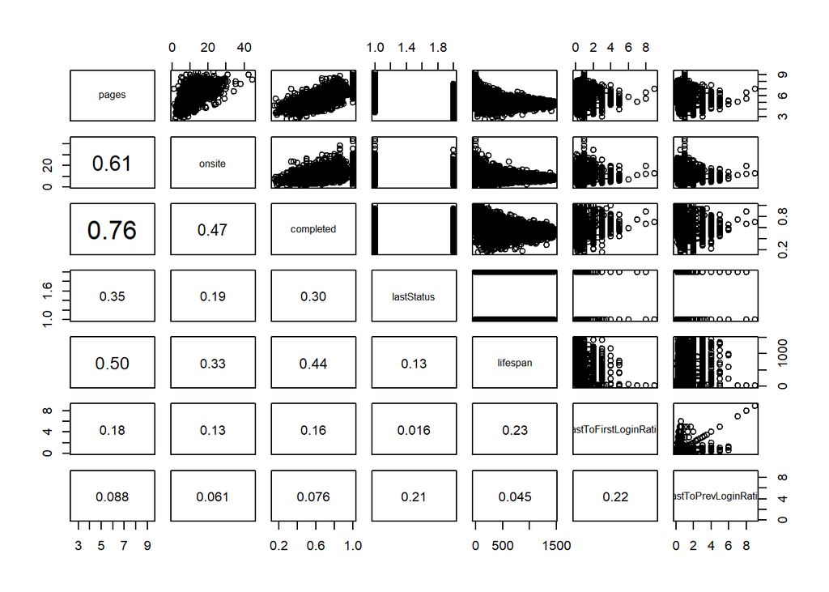

```r
panel.cor <- function(x, y, digits = 2, prefix = "", cex.cor, ...)
{
    usr <- par("usr"); on.exit(par(usr))
    par(usr = c(0, 1, 0, 1))
    r <- abs(cor(x, y))
    txt <- format(c(r, 0.123456789), digits = digits)[1]
    txt <- paste0(prefix, txt)
    if(missing(cex.cor)) cex.cor <- 0.8/strwidth(txt)
    text(0.5, 0.5, txt, cex = pmax(1, cex.cor * r))
}

# Use panel.cor to display correlations in lower panel.
pairs(customer.overall.means[,c(-1)], lower.panel = panel.cor)
```

- From the above plots, we see that most of the predictors have very low correlation among themselves. While `pages` and `completed` have a .76 correlation between them, we still consider both of them as part of the model as the value is not too high to imply complete correlation. Hence removing either could cause the model to miss out on certain insights.
- After the preliminary data processing we create an `ltv_afterProcess` dataset containing the original data from the `customer.data` dataset with the addition of `CompletedVSHoliday` and `OnsiteVSEntered` columns.

| Data Field | Description |
| --- | --- |
| `CompletedVSHoliday` | The ratio of the no. entered vs holiday e-cards attempted |
| `OnsiteVSEntered` | The ratio of the no. onsite vs entered attempts by the customer |
| ——————– | ———————————————————————— |

```r
# Add 2 columns in the dataframe representing completed/holiday and onsite/entered
ltv_afterProcess <- transform(
  customer.data,
  CompletedVSHoliday=as.integer(entered)/as.integer(holiday),
  OnsiteVSEntered=as.integer(onsite)/as.integer(entered)
)

#Summary of the complete data after pre-processing
kable(summary(ltv_afterProcess), digits = c(3, 3, 3, 3), format = "markdown")
```

|  | id | status | gender | date | pages | onsite | entered | completed | holiday | month | year | lifespan | CompletedVSHoliday | OnsiteVSEntered |
| --- | --- | --- | --- | --- | --- | --- | --- | --- | --- | --- | --- | --- | --- | --- |
|  | Min. : 1 | Min. :0.0000 | F:358716 | Min. :2011-01-01 | Min. : 0.000 | Min. : 0.000 | Min. :0.0000 | Min. :0.0000 | Min. :0.0000 | Length:403835 | Length:403835 | Min. : 0.0 | Min. : 1 | Min. : 1 |
|  | 1st Qu.: 2537 | 1st Qu.:1.0000 | M: 45119 | 1st Qu.:2012-06-29 | 1st Qu.: 3.000 | 1st Qu.: 2.000 | 1st Qu.:1.0000 | 1st Qu.:0.0000 | 1st Qu.:0.0000 | Class :character | Class :character | 1st Qu.: 533.0 | 1st Qu.: 1 | 1st Qu.: 3 |
|  | Median : 5025 | Median :1.0000 | NA | Median :2013-05-04 | Median : 5.000 | Median : 5.000 | Median :1.0000 | Median :1.0000 | Median :0.0000 | Mode :character | Mode :character | Median : 788.0 | Median :Inf | Median : 8 |
|  | Mean : 5017 | Mean :0.9909 | NA | Mean :2013-04-10 | Mean : 5.018 | Mean : 8.831 | Mean :0.7821 | Mean :0.5627 | Mean :0.2277 | NA | NA | Mean : 793.9 | Mean :Inf | Mean :Inf |
|  | 3rd Qu.: 7495 | 3rd Qu.:1.0000 | NA | 3rd Qu.:2014-01-26 | 3rd Qu.: 7.000 | 3rd Qu.: 11.000 | 3rd Qu.:1.0000 | 3rd Qu.:1.0000 | 3rd Qu.:0.0000 | NA | NA | 3rd Qu.:1085.0 | 3rd Qu.:Inf | 3rd Qu.: 34 |
|  | Max. :10000 | Max. :2.0000 | NA | Max. :2014-12-31 | Max. :10.000 | Max. :220.000 | Max. :1.0000 | Max. :1.0000 | Max. :1.0000 | NA | NA | Max. :1458.0 | Max. :Inf | Max. :Inf |
|  | NA | NA | NA | NA | NA | NA | NA | NA | NA | NA | NA | NA | NA’s :88011 | NA’s :6317 |

```r
# calculate the ratio between sum of all entered and sum of all completed
SumEnteredVSCompleted <- sum(ltv_afterProcess$entered)/sum(ltv_afterProcess$completed)
SumEnteredVSCompleted
```

```
## [1] 1.389716
```

We then create the `aggregatedCustomerSums` dataframe which represents the sum of each variable - `pages`, `onsite`, `completed`, `entered` and `holiday` per customer. Note this is a summation.

| Data Field | Description |
| --- | --- |
| `id` | The unique identifier of the customer |
| `pages` | The total number of pages visited by the customer. |
| `onsite` | The total number of minutes spent on the site by the customer. |
| `entered` | The total number of sender entered orders by the customer. |
| `completed` | The total number of completed orders by the customer. |
| `holiday` | The total number of holiday orders by the customer. |
| `gender` | User gender ‘M’- male, ‘F’- female. |
| `status` | The final status of the customer taken from the `customer.lifespan` dataset. |
| `lifespan` | The lifespan of the customer taken from the `customer.lifespan` dataset. |
| `decisiveRatio` | The degree to which customers are hestitant to complete the order. This is |
|  | calculated as Sum(`completed`)/Sum(`entered`) for each customer. |
| ———————– | ————————————————————————————- |

```r
# create a new dataframe representing the aggregated summation of each variable per customer
aggregatedCustomerSums <- aggregate(cbind(PagesSum=ltv_afterProcess$pages, OnsiteSum=ltv_afterProcess$onsite, EnteredSum=ltv_afterProcess$entered, CompletedSum=ltv_afterProcess$completed, HolidaySum=ltv_afterProcess$holiday), by=list(Customerid=ltv_afterProcess$id), FUN=sum)
#merge this with the customer data based on id, to retrive the gender column.
aggregatedCustomerSums<-merge(x = aggregatedCustomerSums, y = customer.data, intersect(names(aggregatedCustomerSums), names(customer.data)), by.x = "Customerid", by.y = "id", all.x=TRUE)[,c(names(aggregatedCustomerSums), "gender")]%>% dplyr::distinct(Customerid, .keep_all=TRUE)

aggregatedCustomerSums <- transform(
  aggregatedCustomerSums,
  gender = as.factor(gender),
  status = customer.lifespan$status,
  lifespan = customer.lifespan$lifespan,
  decisiveratio = CompletedSum / EnteredSum
)
aggregatedCustomerSums <- dplyr::rename(aggregatedCustomerSums, id = Customerid, pages = PagesSum, onsite = OnsiteSum, entered = EnteredSum, completed = CompletedSum, holiday = HolidaySum)

#Summary of the aggregated summation of each customer
kable(summary(aggregatedCustomerSums), digits = c(3, 3, 3, 3), format = "markdown")
```

|  | id | pages | onsite | entered | completed | holiday | gender | status | lifespan | decisiveratio |
| --- | --- | --- | --- | --- | --- | --- | --- | --- | --- | --- |
|  | Min. : 1 | Min. : 5.0 | Min. : 1.0 | Min. : 1.00 | Min. : 1.00 | Min. : 0.000 | F:7924 | Min. :1.000 | Min. : 0 | Min. :0.1667 |
|  | 1st Qu.: 2501 | 1st Qu.: 98.0 | 1st Qu.: 169.0 | 1st Qu.: 14.00 | 1st Qu.:11.00 | 1st Qu.: 3.000 | M:2076 | 1st Qu.:1.000 | 1st Qu.: 302 | 1st Qu.:0.6757 |
|  | Median : 5000 | Median :158.0 | Median : 284.5 | Median : 24.00 | Median :18.00 | Median : 7.000 | NA | Median :2.000 | Median : 533 | Median :0.7333 |
|  | Mean : 5000 | Mean :202.6 | Mean : 356.6 | Mean : 31.58 | Mean :22.73 | Mean : 9.195 | NA | Mean :1.632 | Mean : 570 | Mean :0.7455 |
|  | 3rd Qu.: 7500 | 3rd Qu.:277.0 | 3rd Qu.: 484.0 | 3rd Qu.: 43.00 | 3rd Qu.:31.00 | 3rd Qu.:13.000 | NA | 3rd Qu.:2.000 | 3rd Qu.: 805 | 3rd Qu.:0.8000 |
|  | Max. :10000 | Max. :806.0 | Max. :1493.0 | Max. :134.00 | Max. :92.00 | Max. :37.000 | NA | Max. :2.000 | Max. :1458 | Max. :1.0000 |

Given below is the utility method to print out the performance metrics (Accuracy, Sensitivity, Specificity, PPV and NPV) for the models.

```r
classMetrics <- function(conf.mat) {
  n <- sum(conf.mat)

  if (nrow(conf.mat) == 2) {
    accuracy <- (conf.mat[2,2] + conf.mat[1,1])/n
    sensitivity <- conf.mat[2,2]/(conf.mat[2,2]+conf.mat[1,2])
    specificity <- conf.mat[1,1]/(conf.mat[1,1]+conf.mat[2,1])
    ppv <- conf.mat[2,2]/(conf.mat[2,2]+conf.mat[2,1])
    npv <- conf.mat[1,1]/(conf.mat[1,1]+conf.mat[1,2])
  } else if (nrow(conf.mat) == 3) {
    accuracy <- (conf.mat[2,2] + conf.mat[1,1] + conf.mat[3,3])/n
    sensitivity <- conf.mat[3,3]/(conf.mat[3,3]+conf.mat[2,3]+conf.mat[1,3])
    specificity <- (conf.mat[1,2]+conf.mat[1,1]+conf.mat[2,1]+conf.mat[2,2])/(conf.mat[3,2]+conf.mat[2,2]+conf.mat[1,2]+conf.mat[3,1]+conf.mat[2,1]+conf.mat[1,1])
    ppv <- conf.mat[3,3]/(conf.mat[3,1]+conf.mat[3,2]+conf.mat[3,3])
    npv <- (conf.mat[1,2]+conf.mat[1,1]+conf.mat[2,1]+conf.mat[2,2])/(conf.mat[1,1]+conf.mat[1,2]+conf.mat[1,3]+conf.mat[2,1]+conf.mat[2,2]+conf.mat[2,3])
  } else if (nrow(conf.mat) == 4) {
    accuracy <- (conf.mat[2,2] + conf.mat[1,1] + conf.mat[3,3]+ conf.mat[4,4])/n
    sensitivity <- conf.mat[4,4]/(conf.mat[1,4]+conf.mat[2,4]+conf.mat[3,4]+conf.mat[4,4])
    specificity <- (conf.mat[1,1]+conf.mat[1,2]+conf.mat[1,3]+conf.mat[2,1]+conf.mat[2,2]+conf.mat[2,3]+conf.mat[3,1]+conf.mat[3,2]+conf.mat[3,3])/(conf.mat[1,1]+conf.mat[1,2]+conf.mat[1,3]+conf.mat[2,1]+conf.mat[2,2]+conf.mat[2,3]+conf.mat[3,1]+conf.mat[3,2]+conf.mat[3,3]+conf.mat[4,1]+conf.mat[4,2]+conf.mat[4,3])
    ppv <- conf.mat[4,4]/(conf.mat[4,1]+conf.mat[4,2]+conf.mat[4,3]+conf.mat[4,3])
    npv <- (conf.mat[1,1]+conf.mat[1,2]+conf.mat[1,3]+conf.mat[2,1]+conf.mat[2,2]+conf.mat[2,3]+conf.mat[3,1]+conf.mat[3,2]+conf.mat[3,3])/(conf.mat[1,1]+conf.mat[1,2]+conf.mat[1,3]+conf.mat[2,1]+conf.mat[2,2]+conf.mat[2,3]+conf.mat[3,1]+conf.mat[3,2]+conf.mat[3,3]+conf.mat[1,4]+conf.mat[2,4]+conf.mat[3,4])
  }

  result <- data.frame()
  result <- data.frame("value" = c(accuracy, sensitivity, specificity,ppv,npv))
  row.names(result) <- c("accuracy", "sensitivity", "specificity","ppv","npv")

  return(result)
}
```

## 1. Develop an attrition model, to predict whether a customer will cancel their subscription in the near future. Characterize your model performance.

- To address this task, we look into two possible methods of predicting subscription cancellations:
  - In the first method, we segment/cluster the customer base into groups based on their user activity. Using these segments, we predict whether a customer would move into a lesser active/likely to cancel group.
  - In the second method, we classify our customer base on their recent subscription status to determine trends that can be used to predict the how much more likely a customer is to cancel their subscription.

#### First Method: predict whether a customer will cancel their subscription in the near future based on different segments customer

We will try to determine if we can segment the customers into buckets and determine if any behaviour related to their average online time, completed orders can be used to predict whether a customer will cancel their subscription in the near future

- First pass analysis of the predictors that would be used via Clustering and then assosiate the users into the appropriate segments:
  - `Active` - Customers who are actively using the website and likely to keep subscribing
  - `Napping` - Customers who are mostly active but have a few days of almost 0 activity. They are unlikely to cancel their subscription in the near future
  - `Sleepin` - Customers who are not very active and are more likely to leave the subscription in the coming months
  - `Cancelled` - Customers who have cancelled and will cancel for sure.
- Dataset used : `customer.overall.means`
- We first use K-Means to try to cluster our user base.

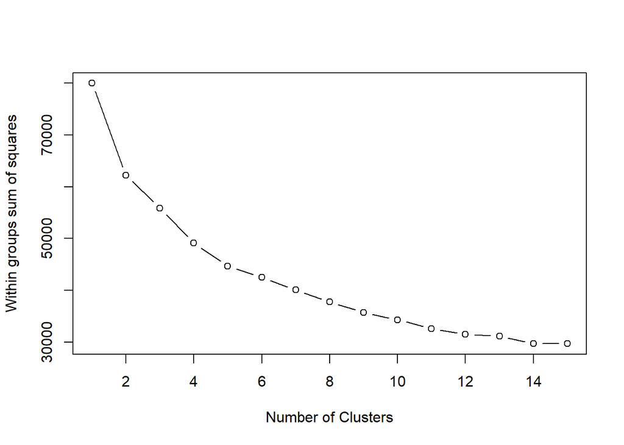

```r
std.customer <- na.omit(customer.overall.means) # listwise deletion of missing
std.customer <- scale(std.customer) # standardize variables
wss <- (nrow(std.customer)-1)*sum(apply(std.customer,2,var))
for (i in 2:15) wss[i] <- sum(kmeans(std.customer,
   centers=i)$withinss)
plot(1:15, wss, type="b", xlab="Number of Clusters",
  ylab="Within groups sum of squares")
```

```r
km.res <- kmeans(std.customer, 4, nstart = 25)
str(km.res)
```

```
## List of 9
##  $ cluster     : Named int [1:10000] 3 4 1 1 4 2 1 4 4 2 ...
##   ..- attr(*, "names")= chr [1:10000] "1" "2" "3" "4" ...
##  $ centers     : num [1:4, 1:8] 0.03124 0.00867 0.00914 -0.0174 -0.12142 ...
##   ..- attr(*, "dimnames")=List of 2
##   .. ..$ : chr [1:4] "1" "2" "3" "4"
##   .. ..$ : chr [1:8] "id" "pages" "onsite" "completed" ...
##  $ totss       : num 79992
##  $ withinss    : num [1:4] 10664 9935 5103 23205
##  $ tot.withinss: num 48908
##  $ betweenss   : num 31084
##  $ size        : int [1:4] 2636 1196 550 5618
##  $ iter        : int 4
##  $ ifault      : int 0
##  - attr(*, "class")= chr "kmeans"
```

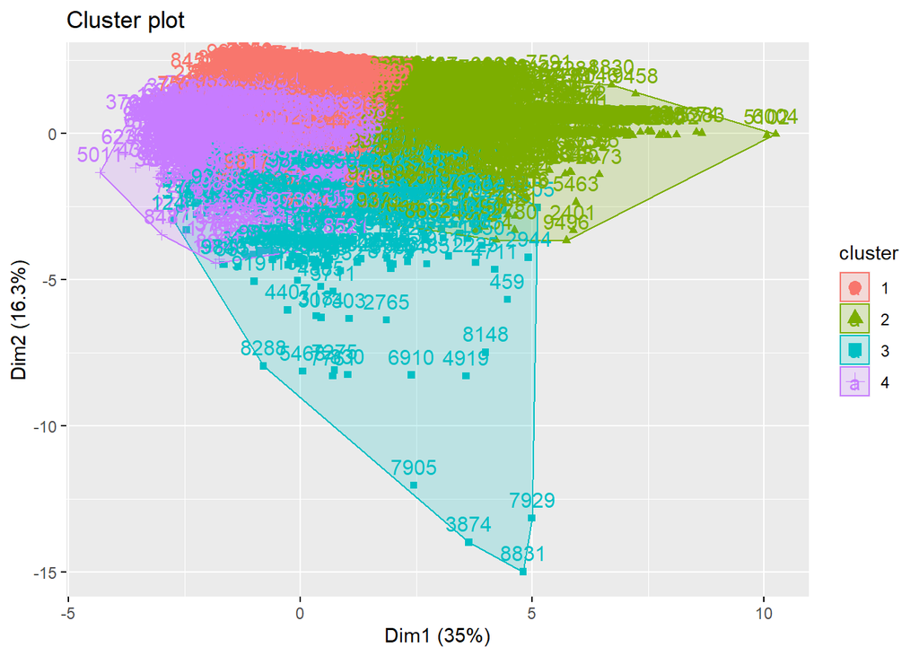

```r
#clusplot(std.customer, km.res$cluster, color=TRUE, shade=TRUE,
#   labels=2, lines=0)
fviz_cluster(km.res, data = std.customer)
```

- K-Means seems to be very crowded and not very interpretatble. Let us try Heirarchical Clustering

```r
set.seed(30)
#Heirarchical Clustering
# we create a 100% data partition from the subset of customers who cancelled
cancelled.customers = createDataPartition(customer.overall.means$id[which(customer.overall.means$lastStatus == 2)],l=F, p = 1)
# we create a 100% data partition from the subset of customers who are active
active.customers = createDataPartition(customer.overall.means$id[which(customer.overall.means$lastStatus == 1)],l=F, p = 1)

customer.train <- rbind(active.customers, cancelled.customers)

#The set is all the customers
scalled.customer = scale(customer.overall.means[,-1])
segmented.customers = customer.overall.means[customer.train,-1 ]
scalled.customer.train  = scalled.customer[customer.train, ]

# Compute distance metrics on the standardized customer data
distanceMatrix = dist(scalled.customer.train)

# Perform hierarchical clustering on distance metrics
hierarchical.cluster <- hclust(distanceMatrix, method = 'ward.D2')
# Build dendrogram object from hierarchical.cluster results
hierarchical.dendogram <- as.dendrogram(hierarchical.cluster)
# Extract the data (for rectangular lines)
hierarchical.dendogram <- dendro_data(hierarchical.dendogram, type = "rectangle")

names(hierarchical.dendogram)
```

```
## [1] "segments"    "labels"      "leaf_labels" "class"
```

```r
head(hierarchical.dendogram$labels)
```

```
##   x y label
## 1 1 0   323
## 2 2 0  4006
## 3 3 0  8838
## 4 4 0  1897
## 5 5 0  5580
## 6 6 0  8195
```

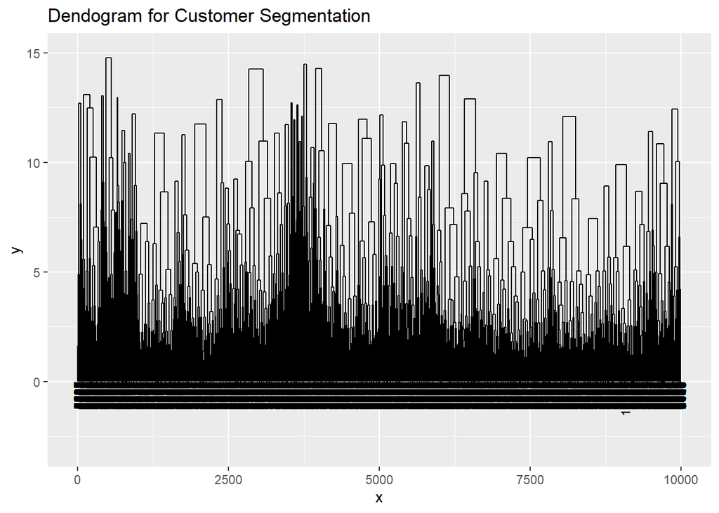

```r
# Plot the dendogram
p <- ggplot(hierarchical.dendogram$segments) +
  geom_segment(aes(x = x, y = y, xend = xend, yend = yend))+
  geom_text(data = hierarchical.dendogram$labels, aes(x, y, label = label),
            hjust = 1, angle = 90, size = 3)+
  ylim(-3, 15)+ ggtitle("Dendogram for Customer Segmentation")
print(p)
```

- The dendogram is too crowded and so we first try 5 segments and view the data

```r
members = cutree(hierarchical.cluster, k = 5)
aggregate(segmented.customers, by = list(members), mean)
```

```
##   Group.1    pages    onsite completed lastStatus lifespan
## 1       1 5.383179  9.763770 0.6136783   1.699659 429.7389
## 2       2 5.369670  9.891896 0.6298206   2.000000 357.8071
## 3       3 5.105999  8.821992 0.5673820   1.000000 649.2413
## 4       4 4.826308  8.335655 0.5301232   2.000000 713.3317
## 5       5 6.664824 14.274636 0.8010912   1.071642 129.3672
##   lastToFirstLoginRatio lastToPrevLoginRatio
## 1             2.4109784             1.669943
## 2             0.3132778             1.068957
## 3             0.2889170             1.100773
## 4             0.3358808             1.526297
## 5             0.6383214             1.005264
```

```r
# decreasing the segments to 4
members = cutree(hierarchical.cluster, k = 4)
segmented.customers.df <- as.data.frame(aggregate(segmented.customers, by = list(members), mean))
segmented.customers.df <- segmented.customers.df %>% dplyr::rename(Type = Group.1)
segmented.customers.df$Type <- c("Sleeping", "Cancelled", "Active", "Napping" )
segmented.customers.df
```

```
##        Type    pages    onsite completed lastStatus lifespan
## 1  Sleeping 5.383179  9.763770 0.6136783   1.699659 429.7389
## 2 Cancelled 4.963601  8.728877 0.5553142   2.000000 623.4997
## 3    Active 5.105999  8.821992 0.5673820   1.000000 649.2413
## 4   Napping 6.664824 14.274636 0.8010912   1.071642 129.3672
##   lastToFirstLoginRatio lastToPrevLoginRatio
## 1             2.4109784             1.669943
## 2             0.3301696             1.410739
## 3             0.2889170             1.100773
## 4             0.6383214             1.005264
```

```r
#Our train set contains all 10,000 users
segmented.customers$segment <- members

#Summary of the customer segmentation data set
kable(summary(segmented.customers), digits = c(3, 3, 3, 3), format = "markdown")
```

|  | pages | onsite | completed | lastStatus | lifespan | lastToFirstLoginRatio | lastToPrevLoginRatio | segment |
| --- | --- | --- | --- | --- | --- | --- | --- | --- |
|  | Min. :2.571 | Min. : 1.000 | Min. :0.1538 | Min. :1.000 | Min. : 0 | Min. :0.05556 | Min. :0.08333 | Min. :1.000 |
|  | 1st Qu.:4.778 | 1st Qu.: 7.596 | 1st Qu.:0.5152 | 1st Qu.:1.000 | 1st Qu.: 304 | 1st Qu.:0.15385 | 1st Qu.:1.00000 | 1st Qu.:2.000 |
|  | Median :5.041 | Median : 8.820 | Median :0.5700 | Median :2.000 | Median : 535 | Median :0.25000 | Median :1.00000 | Median :2.000 |
|  | Mean :5.195 | Mean : 9.370 | Mean :0.5865 | Mean :1.637 | Mean : 569 | Mean :0.47268 | Mean :1.30707 | Mean :2.394 |
|  | 3rd Qu.:5.429 | 3rd Qu.:10.400 | 3rd Qu.:0.6364 | 3rd Qu.:2.000 | 3rd Qu.: 803 | 3rd Qu.:0.50000 | 3rd Qu.:2.00000 | 3rd Qu.:3.000 |
|  | Max. :9.333 | Max. :44.667 | Max. :1.0000 | Max. :2.000 | Max. :1458 | Max. :8.00000 | Max. :8.00000 | Max. :4.000 |

##### QQ plot visualization

We now construct the data to draw the QQ plot to examine the performance of our groupings.

```r
#aggregate the dta
aggregate_customer <- segmented.customers
aggregate_customer$segment.label <- ifelse(aggregate_customer$segment == 1,'sleeping',ifelse(aggregate_customer$segment == 2,'Cancelled',ifelse(aggregate_customer$segment == 3,'Active','Napping')
))
aggregate_customer$status.label <- ifelse(aggregate_customer$lastStatus == 1,'Active User','Non-Active User')
```

Compare the distribution of the original status and the clustering segment. We want to see the differences of order completed based on their quantile distribution.

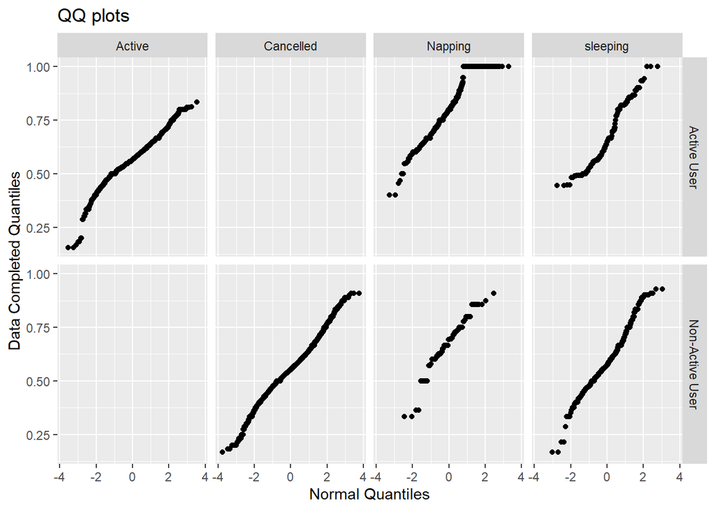

```r
# calculate the normal theoretical quantiles per group
df1 <- ddply(.data = aggregate_customer, .variables = .(status.label,segment.label), function(dat){
             q <- qqnorm(dat$completed, plot = FALSE)
             dat$xq <- q$x
             dat
}
)

# plot the sample values against the theoretical quantiles
ggplot(data = df1, aes(x = xq, y = completed)) +
  geom_point() +
  labs(title = 'QQ plots', x = 'Normal Quantiles', y = 'Data Completed Quantiles')+
  facet_grid(status.label ~ segment.label)
```

```r
#normalize the lifespan
# standardize the birth weights
aggregate_customer = mutate(aggregate_customer,
                 lifespan.norm = (lifespan - min(lifespan,na.rm = TRUE))/
                   (max(lifespan,na.rm = TRUE) - min(lifespan,na.rm = TRUE)))
```

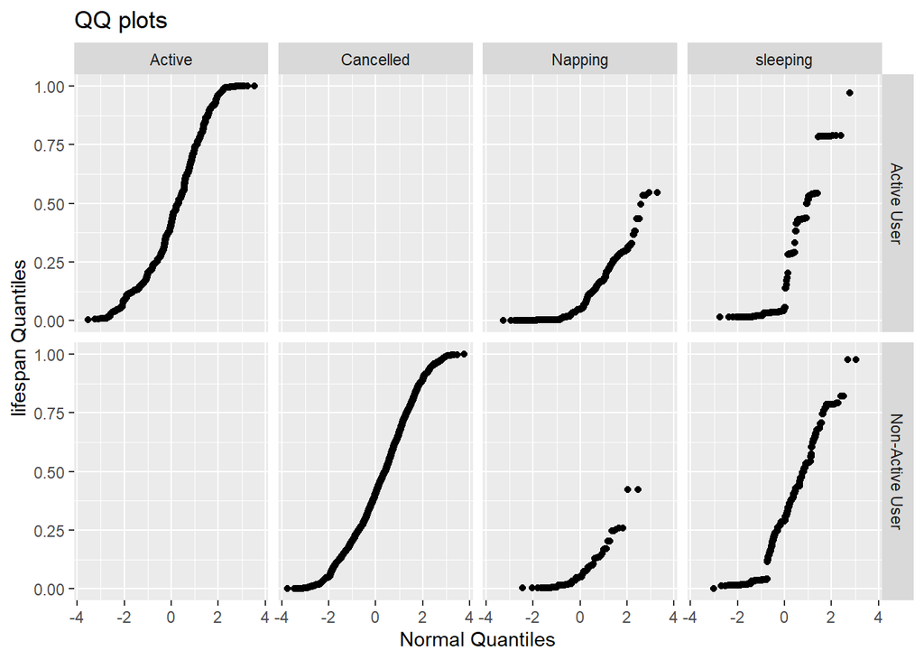

```r
# calculate the normal theoretical quantiles per group
df2 <- ddply(.data = aggregate_customer, .variables = .(status.label,segment.label), function(dat){
             q <- qqnorm(dat$lifespan.norm, plot = FALSE)
             dat$xq <- q$x
             dat
}
)

# plot the sample values against the theoretical quantiles
ggplot(data = df2, aes(x = xq, y = lifespan.norm)) +
  geom_point() +
  labs(title = 'QQ plots', x = 'Normal Quantiles', y = 'lifespan Quantiles')+
  facet_grid(status.label ~ segment.label)
```

##### Predicting via Random Forest

```r
set.seed(1)
# we create a 70:30 data partition from the subset of customers
train.segments = sample(1:nrow(segmented.customers), nrow(segmented.customers)*2/3)

customer.segements.train <- segmented.customers[train.segments, -4]
customer.segements.test <- segmented.customers[-train.segments, -4]

# Random Forest
customer.segements.rf <- randomForest(as.factor(customer.segements.train$segment) ~ . ,data=customer.segements.train, importance=TRUE, ntree=150)
customer.segements.rf
```

```
##
## Call:
##  randomForest(formula = as.factor(customer.segements.train$segment) ~      ., data = customer.segements.train, importance = TRUE, ntree = 150)
##                Type of random forest: classification
##                      Number of trees: 150
## No. of variables tried at each split: 2
##
##         OOB estimate of  error rate: 14.39%
## Confusion matrix:
##     1    2    3   4 class.error
## 1 412    3    0   4  0.01670644
## 2   4 3655  207  64  0.06997455
## 3   0  619 1033   5  0.37658419
## 4   6   40    7 607  0.08030303
```

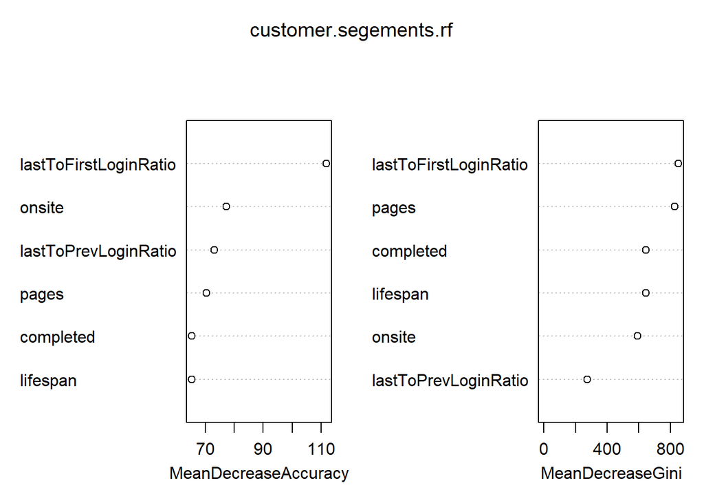

```r
#plotting the importance of the variables in the model
varImpPlot(customer.segements.rf)
```

```r
#creating a model to predict the segments that would move into cancellled
customer.segements.rf.predict <- predict(customer.segements.rf, customer.segements.test)
customer.segements.rf.table <- table(customer.segements.rf.predict, customer.segements.test$segment)
customer.segements.rf.table
```

```
##
## customer.segements.rf.predict    1    2    3    4
##                             1  165    0    0    1
##                             2    2 1833  322   26
##                             3    0   99  540    2
##                             4    0   27    1  316
```

```r
# display the measurement of confusion martixs
classMetrics(customer.segements.rf.table)
```

```
##                  value
## accuracy     0.8560288
## sensitivity  0.9159420
## specificity  0.9906323
## ppv         10.8965517
## npv          0.9903010
```

- We see an accuracy of 85.6% is obtained by using Random Forests to predict if a customer would leave the subscription.

##### Predicting using SVM

```r
#Creating the model
customer.segements.svm <-svm(as.factor(customer.segements.train$segment) ~ . , data = customer.segements.train)
customer.segements.svm
```

```
##
## Call:
## svm(formula = as.factor(customer.segements.train$segment) ~ ., data = customer.segements.train)
##
##
## Parameters:
##    SVM-Type:  C-classification
##  SVM-Kernel:  radial
##        cost:  1
##
## Number of Support Vectors:  3930
```

```r
#We now develop the predict model given the svm model
customer.segements.svm.pred <- predict(customer.segements.svm, customer.segements.test)
#Confusion matric for the same
conf.mat.segments.svm<-table(customer.segements.svm.pred, customer.segements.test$segment)
conf.mat.segments.svm
```

```
##
## customer.segements.svm.pred    1    2    3    4
##                           1  165    1    0    1
##                           2    0 1806  683   27
##                           3    0   95  180    1
##                           4    2   57    0  316
```

```r
# display the measurement of confusion martixs
classMetrics(conf.mat.segments.svm)
```

```
##                 value
## accuracy    0.7399520
## sensitivity 0.9159420
## specificity 0.9802610
## ppv         5.3559322
## npv         0.9901994
```

- SVM provides an accuracy of approximately 74% for the same.
- Hence we conclude that Random forests have a better performance in predicting if a customer will cancel their subscription in the near future based on different segments customer.

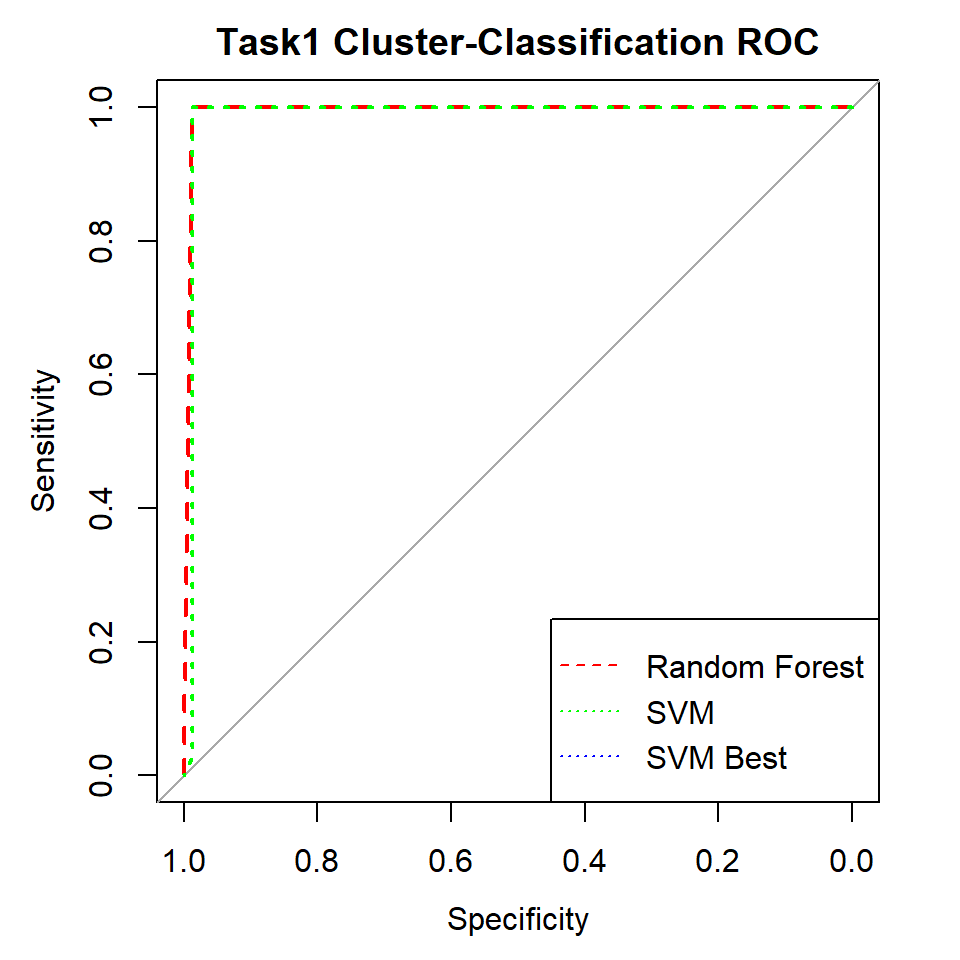

```r
# Plot the performance of each model
roc.Class1.rf <- multiclass.roc(customer.segements.test$segment, as.numeric(customer.segements.rf.predict))
rs <- roc.Class1.rf[['rocs']]
plot.roc(rs[[1]], col = "red", lty=2, main = "Task1 Cluster-Classification ROC")
roc.Class1.svm <- multiclass.roc(customer.segements.test$segment, as.numeric(customer.segements.svm.pred))
rs <- roc.Class1.svm[['rocs']]
plot(rs[[1]], col = "green", lty = 3, add = TRUE)
legend("bottomright", c("Random Forest","SVM","SVM Best"), col = c("red","green","blue"),
       lty = c(2,3,3), pch = c(-1, -1, -1))
```

- The above plot shows the ROC curves for the Random Forest (in red) and the SVM (in green). From the graph, we see that both Random Forests and SVM have almost similar sensitivity (true positive rate), with SVM very minutely varying at the beginning of the sensitivity-specificity threshold.

#### Second Method: Classification on customer status based on statistical features

- Before developing the model, we first create a `customer.classify` dataset, that contains the statistical features (mean, median, standard deviation and skewness) and corresponding ratios for each customer as described below:

| Data Field | Description |
| --- | --- |
| `id` | The unique identifier of the customer |
| `date` | The unique identifier of the customer |
| `status` | The final status of the customer taken from the `customer.lifespan` dataset. |
| `pages` | The total number of pages visited by each customer. |
| `onsite` | The total number of minutes spent on the site by each customer. |
| `entered` | The total number of sender entered orders by each customer. |
| `completed` | The total number of completed orders by each customer. |
| `holiday` | The total number of holiday orders by each customer. |
| `gender` | User gender ‘M’- male, ‘F’- female. |
| `avgOnsite` | The average number of minutes spent on the site by each customer. |
| `medOnsite` | The median of minutes spent on the site by each customer. |
| `sdOnsite` | The standard deviation of minutes spent on the site by each customer. |
| `skewOnsite` | The skewness in minutes spent on the site by each customer. |
| `avgPages` | The average number of pages visited by each customer. |
| `medPages` | The median of pages visited by each customer. |
| `sdPages` | The standard deviation of pages visited by each customer. |
| `skewPages` | The skewness of pages visited by each customer. |
| `avgEntered` | The average number of sender entered ecards by each customer. |
| `avgCompleted` | The average number of completed orders by each customer. |
| `avgHoliday` | The average number of holiday orders by each customer. |
| `enterPerPage` | The average of entered by pages for each customer. |
| `completePerEnter` | The ratio of total completed orders to entered for each customer. |
| `onsitePerEnter` | The ratio of total onsite visits to entered ecards for each customer. |
| `onsitePerPage` | The average of onsite visits by pages for each customer. |
| `pagesPerHoliday` | The average of holidays orders by pages for each customer. |
| `onsitePerHoliday` | The average of onsite visits by pages for each customer. |
| `LastMonthOnsiteTime` | The onsite time in minutes for the last month visit by the customer. |
| `LastMonthPagesViewed` | The number of pages visited in the last month by each customer. |
| ———————– | ————————————————————————————- |

```r
#group the selected columns based on the customer ID
customer.classify <- customer.data[, c("id", "date", "status", "pages", "onsite", "entered", "completed", "holiday", "gender")] %>% group_by(id)
#add to the data set, statistical features - mean, median, standard deviation and skewness
customer.classify <-customer.classify %>% dplyr::mutate(avgOnsite = mean(onsite))
customer.classify <-customer.classify %>% dplyr::mutate(medOnsite = median(onsite))
customer.classify <-customer.classify %>% dplyr::mutate(sdOnsite = sd(onsite))
customer.classify <-customer.classify %>% dplyr::mutate(skewOnsite = skewness(onsite))
customer.classify <-customer.classify %>% dplyr::mutate(avgPages = mean(pages))
customer.classify <-customer.classify %>% dplyr::mutate(medPages = median(pages))
customer.classify <-customer.classify %>% dplyr::mutate(sdPages = sd(pages))
customer.classify <-customer.classify %>% dplyr::mutate(skewPages = skewness(pages))
customer.classify <-customer.classify %>% dplyr::mutate(avgEntered = mean(entered))
customer.classify <-customer.classify %>% dplyr::mutate(avgCompleted = mean(completed))
customer.classify <-customer.classify %>% dplyr::mutate(avgHoliday = mean(holiday))
customer.classify<-customer.classify %>% dplyr::mutate(enterPerPage = mean(entered/pages, na.rm = TRUE))
customer.classify<-customer.classify %>% dplyr::mutate(completePerEnter = sum(completed)/sum(entered))
customer.classify<-customer.classify %>% dplyr::mutate(onsitePerEnter = sum(onsite)/sum(entered))
customer.classify<-customer.classify %>% dplyr::mutate(onsitePerPage = mean(onsite/pages, na.rm = TRUE))
customer.classify<-customer.classify %>% dplyr::mutate(pagesPerHoliday = mean(holiday/pages, na.rm = TRUE))
customer.classify<-customer.classify %>% dplyr::mutate(onsitePerHoliday = mean(holiday/onsite, na.rm = TRUE))
customer.classify <-customer.classify %>% dplyr::mutate(LastMonthOnsiteTime = tail(onsite, n=2)[1])
customer.classify <-customer.classify %>% dplyr::mutate(LastMonthPagesViewed = tail(pages, n=2)[1])

#Ensure the set only contains distinct values for ID
customer.classify <- customer.classify %>% dplyr::distinct(id, .keep_all = TRUE)

#add in the below columns from the aggregatedCustomerSums dataset
customer.classify <- transform(
  customer.classify,
  status = aggregatedCustomerSums$status,
  pages = aggregatedCustomerSums$pages,
  onsite = aggregatedCustomerSums$onsite,
  entered = aggregatedCustomerSums$entered,
  completed = aggregatedCustomerSums$completed,
  holiday = aggregatedCustomerSums$holiday
)

customer.classify<-transform(
  customer.classify,
  status = as.factor(status)
)

#Summary of the customer classification pre-processed data set
kable(summary(customer.classify), digits = c(3, 3, 3, 3), format = "markdown")
```

|  | id | date | status | pages | onsite | entered | completed | holiday | gender | avgOnsite | medOnsite | sdOnsite | skewOnsite | avgPages | medPages | sdPages | skewPages | avgEntered | avgCompleted | avgHoliday | enterPerPage | completePerEnter | onsitePerEnter | onsitePerPage | pagesPerHoliday | onsitePerHoliday | LastMonthOnsiteTime | LastMonthPagesViewed |
| --- | --- | --- | --- | --- | --- | --- | --- | --- | --- | --- | --- | --- | --- | --- | --- | --- | --- | --- | --- | --- | --- | --- | --- | --- | --- | --- | --- | --- |
|  | Min. : 1 | Min. :2011-01-01 | 1:3683 | Min. : 5.0 | Min. : 1.0 | Min. : 1.00 | Min. : 1.00 | Min. : 0.000 | F:7924 | Min. : 1.000 | Min. : 1.00 | Min. : 0.9258 | Min. :-0.6219 | Min. :2.571 | Min. :1.000 | Min. :0.000 | Min. :-2.03605 | Min. :0.2500 | Min. :0.1538 | Min. :0.0000 | Min. :0.03214 | Min. :0.1667 | Min. : 1.000 | Min. :0.1429 | Min. :0.00000 | Min. :0.00000 | Min. : 1.000 | Min. : 1.000 |
|  | 1st Qu.: 2501 | 1st Qu.:2011-12-25 | 2:6317 | 1st Qu.: 98.0 | 1st Qu.: 169.0 | 1st Qu.: 14.00 | 1st Qu.:11.00 | 1st Qu.: 3.000 | M:2076 | 1st Qu.: 7.577 | 1st Qu.: 4.00 | 1st Qu.: 8.6296 | 1st Qu.: 1.3209 | 1st Qu.:4.778 | 1st Qu.:4.000 | 1st Qu.:2.449 | 1st Qu.:-0.08758 | 1st Qu.:0.7368 | 1st Qu.:0.5152 | 1st Qu.:0.1739 | 1st Qu.:0.15650 | 1st Qu.:0.6757 | 1st Qu.: 9.735 | 1st Qu.:1.4698 | 1st Qu.:0.02440 | 1st Qu.:0.02345 | 1st Qu.: 1.000 | 1st Qu.: 2.000 |
|  | Median : 5000 | Median :2013-01-01 | NA | Median :158.0 | Median : 284.5 | Median : 24.00 | Median :18.00 | Median : 7.000 | NA | Median : 8.792 | Median : 5.00 | Median :10.7587 | Median : 1.8892 | Median :5.045 | Median :5.000 | Median :2.611 | Median : 0.17322 | Median :0.7863 | Median :0.5714 | Median :0.2198 | Median :0.17595 | Median :0.7333 | Median :11.308 | Median :1.6443 | Median :0.03062 | Median :0.04015 | Median : 3.000 | Median : 4.000 |
|  | Mean : 5000 | Mean :2013-01-03 | NA | Mean :202.6 | Mean : 356.6 | Mean : 31.58 | Mean :22.73 | Mean : 9.195 | NA | Mean : 9.363 | Mean : 5.26 | Mean :11.4334 | Mean : 1.9551 | Mean :5.196 | Mean :4.936 | Mean :2.612 | Mean : 0.10201 | Mean :0.7857 | Mean :0.5875 | Mean :0.2101 | Mean :0.17365 | Mean :0.7455 | Mean :11.930 | Mean :1.6877 | Mean :0.03065 | Mean :0.04372 | Mean : 6.942 | Mean : 4.196 |
|  | 3rd Qu.: 7500 | 3rd Qu.:2013-12-25 | NA | 3rd Qu.:277.0 | 3rd Qu.: 484.0 | 3rd Qu.: 43.00 | 3rd Qu.:31.00 | 3rd Qu.:13.000 | NA | 3rd Qu.:10.412 | 3rd Qu.: 6.00 | 3rd Qu.:13.4049 | 3rd Qu.: 2.4988 | 3rd Qu.:5.429 | 3rd Qu.:5.500 | 3rd Qu.:2.789 | 3rd Qu.: 0.36412 | 3rd Qu.:0.8333 | 3rd Qu.:0.6389 | 3rd Qu.:0.2535 | 3rd Qu.:0.19248 | 3rd Qu.:0.8000 | 3rd Qu.:13.316 | 3rd Qu.:1.8407 | 3rd Qu.:0.03670 | 3rd Qu.:0.05843 | 3rd Qu.: 8.000 | 3rd Qu.: 6.000 |
|  | Max. :10000 | Max. :2014-12-30 | NA | Max. :806.0 | Max. :1493.0 | Max. :134.00 | Max. :92.00 | Max. :37.000 | NA | Max. :44.667 | Max. :43.00 | Max. :59.7114 | Max. : 7.1862 | Max. :9.400 | Max. :9.500 | Max. :6.364 | Max. : 1.19462 | Max. :1.0000 | Max. :1.0000 | Max. :0.5455 | Max. :0.37500 | Max. :1.0000 | Max. :51.500 | Max. :5.4180 | Max. :0.17778 | Max. :0.44444 | Max. :119.000 | Max. :10.000 |
|  | NA | NA | NA | NA | NA | NA | NA | NA | NA | NA | NA | NA’s :2 | NA’s :2 | NA | NA | NA’s :2 | NA’s :7 | NA | NA | NA | NA | NA | NA | NA | NA | NA | NA | NA |

We need to drop the `id` and `date` columns from the `customer.classify` dataset since we using these predictors will result in an incorrect model for our task.

```r
customer.classify.drop <- c("id","date")
customer.classify <- customer.classify[,!(names(customer.classify) %in% customer.classify.drop)]
```

```r
# Classification method for task 1
# Define training set
set.seed(42)
classify.train<-sample(1:nrow(customer.classify), nrow(customer.classify)*2/3)
customer.classify.train <- customer.classify[classify.train,]
customer.classify.test <- customer.classify[-classify.train,]
```

We build 4 models using Logistic Regression, Random Forests, Naive Bayes and SVM to predict if a customer would cancel their subscription or not. All these models use `status` as their output variable with all other variables acting as predictors.

##### Predicting using Logistic Regression

```r
#create the logistic regression model and use the model for predicting using the test set
customer.classify.logit <- glm(as.factor(status)~., data = customer.classify.train, family="binomial")
customer.classify.logit.probs <- predict(customer.classify.logit, customer.classify.test, type="response")
summary(customer.classify.logit)
```

```
##
## Call:
## glm(formula = as.factor(status) ~ ., family = "binomial", data = customer.classify.train)
##
## Deviance Residuals:
##     Min       1Q   Median       3Q      Max
## -3.9423  -0.5061   0.2617   0.6548   2.4563
##
## Coefficients:
##                        Estimate Std. Error z value Pr(>|z|)
## (Intercept)           1.584e+01  2.674e+00   5.923 3.16e-09 ***
## pages                 1.545e-02  3.743e-03   4.128 3.66e-05 ***
## onsite                4.890e-04  8.177e-04   0.598 0.549890
## entered              -5.737e-02  2.096e-02  -2.737 0.006196 **
## completed             6.507e-02  2.277e-02   2.858 0.004267 **
## holiday              -1.934e-01  3.076e-02  -6.289 3.20e-10 ***
## genderM              -1.166e+00  1.285e-01  -9.076  < 2e-16 ***
## avgOnsite             1.170e-01  1.418e-01   0.825 0.409305
## medOnsite             6.625e-02  3.945e-02   1.679 0.093081 .
## sdOnsite              3.386e-02  3.702e-02   0.915 0.360417
## skewOnsite            1.121e-01  8.011e-02   1.400 0.161587
## avgPages             -3.471e+00  2.887e-01 -12.021  < 2e-16 ***
## medPages             -5.644e-01  8.641e-02  -6.531 6.53e-11 ***
## sdPages               4.686e+00  2.073e-01  22.601  < 2e-16 ***
## skewPages            -8.762e+00  3.028e-01 -28.933  < 2e-16 ***
## avgEntered           -1.369e+01  3.586e+00  -3.818 0.000134 ***
## avgCompleted         -6.299e-01  4.350e+00  -0.145 0.884880
## avgHoliday           -9.698e+00  1.912e+00  -5.073 3.93e-07 ***
## enterPerPage          3.300e+01  4.058e+00   8.131 4.25e-16 ***
## completePerEnter     -3.727e+00  3.363e+00  -1.108 0.267768
## onsitePerEnter       -1.649e-01  8.922e-02  -1.848 0.064659 .
## onsitePerPage        -2.355e-01  3.849e-01  -0.612 0.540578
## pagesPerHoliday       1.128e+02  1.065e+01  10.593  < 2e-16 ***
## onsitePerHoliday     -8.158e-01  1.843e+00  -0.443 0.657934
## LastMonthOnsiteTime  -1.058e-03  4.213e-03  -0.251 0.801794
## LastMonthPagesViewed  3.861e-02  1.735e-02   2.226 0.026004 *
## ---
## Signif. codes:  0 '***' 0.001 '**' 0.01 '*' 0.05 '.' 0.1 ' ' 1
##
## (Dispersion parameter for binomial family taken to be 1)
##
##     Null deviance: 8776.2  on 6658  degrees of freedom
## Residual deviance: 5257.6  on 6633  degrees of freedom
##   (7 observations deleted due to missingness)
## AIC: 5309.6
##
## Number of Fisher Scoring iterations: 7
```

```r
#Using alpha as 0.5, classify predictions as 2 if the values are above 0.5
customer.classify.logit.pred = rep("1",nrow(customer.classify.test))
customer.classify.logit.pred[customer.classify.logit.probs>0.5] = "2"

#Display the confusion matrix
customer.classify.logit.table <- table(customer.classify.logit.pred, customer.classify.test$status)
customer.classify.logit.table
```

```
##
## customer.classify.logit.pred    1    2
##                            1  868  205
##                            2  344 1917
```

```r
# display the measurement of confusion martixs
classMetrics(customer.classify.logit.table)
```

```
##                 value
## accuracy    0.8353329
## sensitivity 0.9033930
## specificity 0.7161716
## ppv         0.8478549
## npv         0.8089469
```

- The logistic regression has an accuracy of 83.53%. This is a good classification.

##### Predicting using Random Forest

```r
# build the random forest model for classification
customer.classify.rf <- randomForest(status~., data=customer.classify.train, ntree=500, proximity=T,na.action = na.roughfix)
customer.classify.rf
```

```
##
## Call:
##  randomForest(formula = status ~ ., data = customer.classify.train,      ntree = 500, proximity = T, na.action = na.roughfix)
##                Type of random forest: classification
##                      Number of trees: 500
## No. of variables tried at each split: 5
##
##         OOB estimate of  error rate: 21.36%
## Confusion matrix:
##      1    2 class.error
## 1 1414 1057   0.4277620
## 2  367 3828   0.0874851
```

```r
customer.classify.rf.predict <- predict(customer.classify.rf, customer.classify.test)
customer.classify.rf.table <- table(customer.classify.rf.predict, customer.classify.test$status)
customer.classify.rf.table
```

```
##
## customer.classify.rf.predict    1    2
##                            1  739  183
##                            2  473 1939
```

```r
# display the measurement of confusion martixs
classMetrics(customer.classify.rf.table)
```

```
##                 value
## accuracy    0.8032394
## sensitivity 0.9137606
## specificity 0.6097360
## ppv         0.8038972
## npv         0.8015184
```

- The random forest model provides an accuracy of 80.32%. It does not perform as well as the Logistic Regression.

##### Predicting using Naive Bayes

```r
# build the naive bayes model
customer.classify.nb <-naiveBayes(status ~., data = customer.classify.train, laplace=1)
summary(customer.classify.nb)
```

```
##           Length Class  Mode
## apriori    2     table  numeric
## tables    25     -none- list
## levels     2     -none- character
## isnumeric 25     -none- logical
## call       4     -none- call
```

```r
customer.classify.nb.pred <- predict(customer.classify.nb, customer.classify.test)

customer.classify.nb.table<-table(customer.classify.nb.pred, customer.classify.test$status)
customer.classify.nb.table
```

```
##
## customer.classify.nb.pred    1    2
##                         1  464  298
##                         2  748 1824
```

```r
# display the measurement of confusion martixs
classMetrics(customer.classify.nb.table)
```

```
##                 value
## accuracy    0.6862627
## sensitivity 0.8595664
## specificity 0.3828383
## ppv         0.7091757
## npv         0.6089239
```

##### Predicting using SVM

```r
# create the SVM model
customer.classify.svm <-svm(status~ . , data = customer.classify.train, type = 'C-classification', kernel = 'radial')
customer.classify.svm.pred <- predict(customer.classify.svm, customer.classify.test)

customer.classify.svm.table<-table(customer.classify.svm.pred, customer.classify.test$status)
customer.classify.svm.table
```

```
##
## customer.classify.svm.pred    1    2
##                          1  851  173
##                          2  361 1949
```

```r
# display the measurement of confusion martixs
classMetrics(customer.classify.svm.table)
```

```
##                 value
## accuracy    0.8398320
## sensitivity 0.9184731
## specificity 0.7021452
## ppv         0.8437229
## npv         0.8310547
```

- SVM appears to be the best model with an accuracy of 83.98% and overall metrics, with the logistic regression model following closely behind.

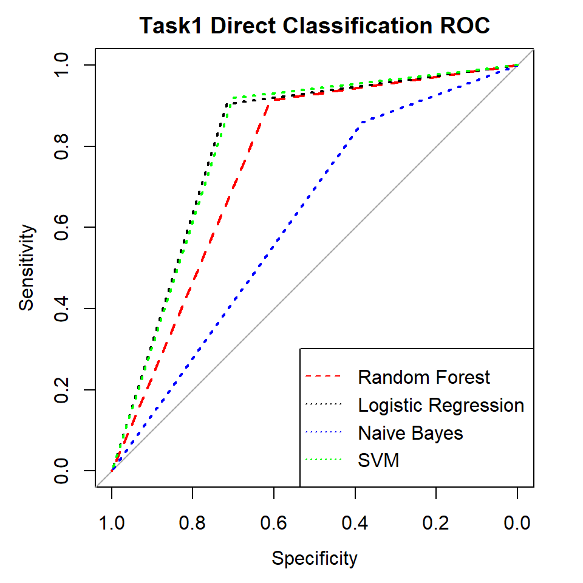

```r
# Plotthe performance of each model
roc.Class2.rf <- multiclass.roc(customer.classify.test$status, as.numeric(customer.classify.rf.predict))
rs <- roc.Class2.rf[['rocs']]
plot.roc(rs[[1]], col = "red", lty=2, main = "Task1 Direct Classification ROC")
roc.Class2.logit <- multiclass.roc(customer.classify.test$status, as.numeric(customer.classify.logit.pred))
rs <- roc.Class2.logit[['rocs']]
plot(rs[[1]], col = "black", lty = 3, add = TRUE)
roc.Class2.nb <- multiclass.roc(customer.classify.test$status, as.numeric(customer.classify.nb.pred))
rs <- roc.Class2.nb[['rocs']]
plot(rs[[1]], col = "blue", lty = 3, add = TRUE)
roc.Class2.svm <- multiclass.roc(customer.classify.test$status, as.numeric(customer.classify.svm.pred))
rs <- roc.Class2.svm[['rocs']]
plot(rs[[1]], col = "green", lty = 3, add = TRUE)
legend("bottomright", c("Random Forest","Logistic Regression","Naive Bayes","SVM"), col = c("red","black","blue","green"),
       lty = c(2,3,3,3), pch = c(-1, -1, -1, -1))
```

- The above plot shows the ROC curves for the Random Forest (in red), Logistic Regression (in black), Naive Bayes (in blue) and the SVM (in green). From the graph, we see that both Logistic Regression and SVM have almost similar sensitivity (true positive rate), with SVM very minutely having a higher sensitivity-specificity threshold with higher sensitivity/specificity. As specificity increases Random forests also meet the same level of sensitivity as Logistic Regression and SVM.

## 2. Develop a model for estimating the ltv of a customer. Characterize your model performance.

We use the `aggregatedCustomerSums` dataset with the addition of the `lifespan` in terms of months. This new term is called the `lifespanByMonth`. From this new dataset called the `aggregatedCustomerSumsTask2`, we drop predictors that will not help with the model performance as shown in the below code.

```r
aggregatedCustomerSumsTask2 <- transform(
  aggregatedCustomerSums,
  lifespanByMonth = ceiling(lifespan/30)
)

aggregatedCustomerSumsTask2.drop <- c("id","status","gender","lifespan","decisiveratio","holiday.ratio","holiday.user")
aggregatedCustomerSumsTask2 <- aggregatedCustomerSumsTask2[,!(names(aggregatedCustomerSumsTask2) %in% aggregatedCustomerSumsTask2.drop)]
```

Using this, we now cluster the data into 3 LTV groups Low, Medium and High via K-Means.

```r
set.seed(42)
#K-means Clustering
aggregatedCustomerSumsTask2 <- na.omit(aggregatedCustomerSumsTask2) # listwise deletion of missing
std.aggregatedCustomerSumsTask2 <- rescale(data.matrix(aggregatedCustomerSumsTask2)) # standardize variables
wss <- (nrow(std.aggregatedCustomerSumsTask2)-1)*sum(apply(std.aggregatedCustomerSumsTask2,2,var))
for (i in 2:15) wss[i] <- sum(kmeans(std.aggregatedCustomerSumsTask2,
   centers=i)$withinss)
```

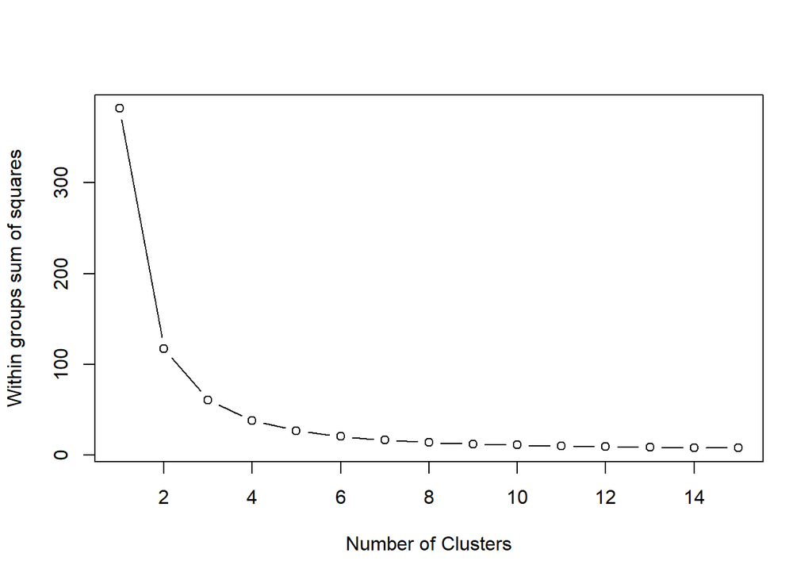

```r
plot(1:15, wss, type="b", xlab="Number of Clusters",
  ylab="Within groups sum of squares")
```

```r
km.ltv <- kmeans(std.aggregatedCustomerSumsTask2, 3, nstart = 25)
str(km.ltv)
```

```
## List of 9
##  $ cluster     : Named int [1:10000] 3 3 3 3 3 3 3 3 2 3 ...
##   ..- attr(*, "names")= chr [1:10000] "1" "2" "3" "4" ...
##  $ centers     : num [1:3, 1:6] 0.1768 0.3252 0.0712 0.3129 0.5773 ...
##   ..- attr(*, "dimnames")=List of 2
##   .. ..$ : chr [1:3] "1" "2" "3"
##   .. ..$ : chr [1:6] "pages" "onsite" "entered" "completed" ...
##  $ totss       : num 382
##  $ withinss    : num [1:3] 18.5 20.3 21.9
##  $ tot.withinss: num 60.7
##  $ betweenss   : num 321
##  $ size        : int [1:3] 2980 1302 5718
##  $ iter        : int 2
##  $ ifault      : int 0
##  - attr(*, "class")= chr "kmeans"
```

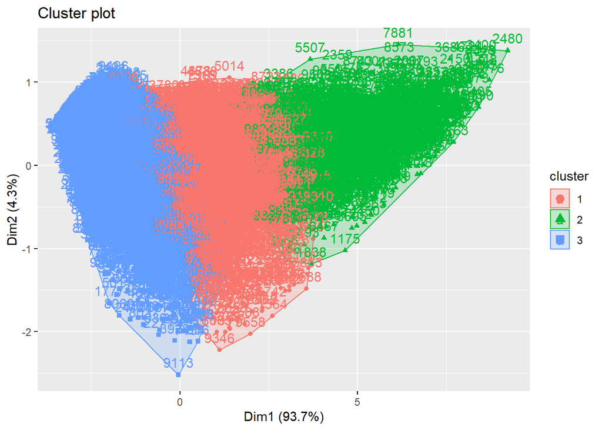

```r
fviz_cluster(km.ltv, data = std.aggregatedCustomerSumsTask2)
```

- Using these new groupings, a new dataset called `clustered.ltv` is created with the following columns:

```r
clustered.ltv <- data.frame(km.ltv$centers)
clustered.ltv <- data.frame(Type = c("Medium LTV", "High LTV", "Low LTV"),clustered.ltv)
clustered.ltv <- transform (
  clustered.ltv,
  pages = pages * max(aggregatedCustomerSumsTask2),
  onsite = onsite * max(aggregatedCustomerSumsTask2),
  entered = entered * max(aggregatedCustomerSumsTask2),
  completed = completed * max(aggregatedCustomerSumsTask2),
  lifespanByMonth = lifespanByMonth * max(aggregatedCustomerSumsTask2)
)

clustered.ltv$lifetimeValue = clustered.ltv$lifespanByMonth * 1
clustered.ltv
```

```
##         Type    pages   onsite  entered completed     holiday lifespanByMonth
## 1 Medium LTV 263.9993 467.1419 41.35537  29.50101 0.008405220        25.02517
## 2   High LTV 485.4800 861.9670 77.89017  54.28495 0.015733433        37.76037
## 3    Low LTV 106.2733 183.9935 15.94474  12.00874 0.002808138        12.43494
##   lifetimeValue
## 1      25.02517
## 2      37.76037
## 3      12.43494
```

## 3. Develop a customer segmentation scheme. Include in this scheme the identification of sleeping customers, those that are no longer active but have not canceled their account.

- There are multiple ways we can segment the customers. For this task we look into two possible ways of doing so:
  - In the first segmentation, we group the customer base into Regularly active, Sleeping and Inactive customers. We also try to understand the possibility of groups based on Holiday vs Non-Holiday users.
  - In the second segmentation, we group customers based on their decisiveness in placing orders i.e. Decisive, Tentative and Hesitant customers.

#### Segmentation 1: Regular(users who have completed regularly irrespective of holidays), Sleeping, Inactive (canceled); Holiday User and Non Holiday use

- In this section, the holiday user label depends on the proportion of the aggregrated sum of orders which completed in holiday, we treat the quantile distribution which larger than the third quantaile as the holiday user.

```r
aggregatedCustomerSums$holiday.ratio <- aggregatedCustomerSums$holiday/aggregatedCustomerSums$completed
summary(aggregatedCustomerSums$holiday.ratio)
```

```
##    Min. 1st Qu.  Median    Mean 3rd Qu.    Max.
##  0.0000  0.2941  0.3889  0.3719  0.4573  0.8889
```

```r
aggregatedCustomerSums$holiday.user <- ifelse(aggregatedCustomerSums$holiday.ratio>0.4573,1,0)
```

- Variables: Completed, pages, onsite, entered
- Classification label: Regular/Sleeping/Inactive
  - 3: if the customer has status as 2 or if they have not visited the website on the given date, then customer is inactive.
  - 2: if the customer has browsed the website >60 days of `12/31/2014` then classify the customer as sleeping.
  - 1: if the customer has recently browsed the website has been active within 60 days of `12/31/2014` then classify the customer as active.

```r
width = length(customer.data)
len = length(customer.data$id)
user.type = rep(0, times = len)
previd = customer.data[1][1]
startid = previd
for(i in seq(len)){
  startid = customer.data[i,1]
  if(customer.data[i,2] == 2){
    user.type[i] = 3
  }else if(startid!=previd){
    diff = (as.Date('12/31/2014','%m/%d/%Y') - customer.data[i-1,4])
    if(diff>60){
      user.type[i-1] = 2
      user.type[i] = 1
    }else{
      user.type[i] = 1
    }
  }else{
    user.type[i] = 1
  }
  previd = startid
}
customer.data$userType <- user.type
```

From the `customer.data` dataset, we pick the below for our model.

[output not shown]

```r
#select the data we need, we do not want to overfit the model, and hence will only include all the data.
# maxDate related data for the each user.
customer.data.segOne <- customer.data %>% group_by(id) %>% filter(date == max(date))
customer.data.segOne <- subset(customer.data.segOne,select = c('pages','onsite', 'userType'))

#split into training and test dataset
customer.data.segOne <- transform(
  customer.data.segOne,
  pages=as.integer(pages),
  onsite=as.integer(onsite),
  userType = as.factor(userType)
)

#Summary of the customer classification for differnet user type
kable(summary(customer.data.segOne), digits = c(3, 3, 3, 3), format = "markdown")
```

|  | pages | onsite | userType |
| --- | --- | --- | --- |
|  | Min. : 0.000 | Min. : 0.000 | 1:4038 |
|  | 1st Qu.: 0.000 | 1st Qu.: 0.000 | 2:4356 |
|  | Median : 0.000 | Median : 0.000 | 3:2437 |
|  | Mean : 2.133 | Mean : 3.816 | NA |
|  | 3rd Qu.: 4.000 | 3rd Qu.: 3.000 | NA |
|  | Max. :10.000 | Max. :132.000 | NA |

```r
set.seed(1)
dt = sort(sample(nrow(customer.data.segOne), nrow(customer.data.segOne)*.7))
train.segOne<-customer.data.segOne[dt,]
test.segOne<-customer.data.segOne[-dt,]
```

– In this section, we would use different classfication models to predict the user type based on the total page number and total onsite minutes. The result will be analyzed by confusion matrix and several classifer performance metrics.

##### Predicting using Random Forest

```r
customer.segOne.rf <- randomForest(
  as.factor(userType) ~ .,
  data = train.segOne,
  importance = TRUE,
  num.trees = 500
)

customer.segOne.rf
```

```
##
## Call:
##  randomForest(formula = as.factor(userType) ~ ., data = train.segOne,      importance = TRUE, num.trees = 500)
##                Type of random forest: classification
##                      Number of trees: 500
## No. of variables tried at each split: 1
##
##         OOB estimate of  error rate: 26.71%
## Confusion matrix:
##      1    2 3 class.error
## 1 2831    0 0   0.0000000
## 2  331 2725 0   0.1083115
## 3    0 1694 0   1.0000000
```

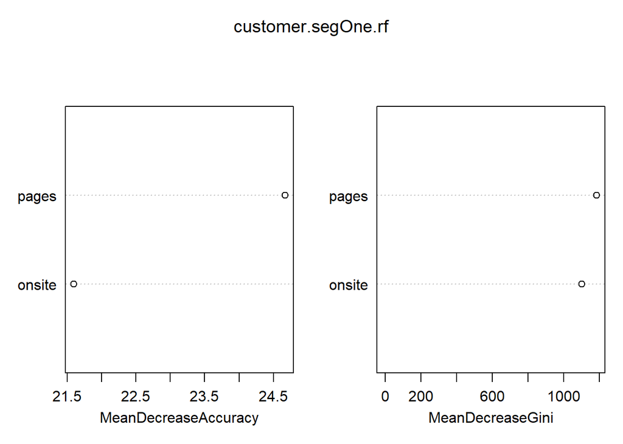

```r
varImpPlot(customer.segOne.rf)
```

```r
customer.segOne.pred <- predict(customer.segOne.rf, test.segOne)
customer.segOne.rfResult<- table(test.segOne$userType, customer.segOne.pred)
customer.segOne.rfResult
```

```
##    customer.segOne.pred
##        1    2    3
##   1 1207    0    0
##   2  145 1155    0
##   3    0  743    0
```

```r
# display the measurement of confusion martixs
classMetrics(customer.segOne.rfResult)
```

```
##                 value
## accuracy    0.7267692
## sensitivity       NaN
## specificity 0.7713846
## ppv         0.0000000
## npv         1.0000000
```

##### Predicting using Logistic Regression

```r
#create the logistic regression model with output as userType and inputs as pages, onsite, entered and completed.
customer.segOne.lr <- multinom(train.segOne$userType ~ . , data = train.segOne)
customer.segOne.lr
```

```
## Call:
## multinom(formula = train.segOne$userType ~ ., data = train.segOne)
##
## Coefficients:
##   (Intercept)     pages       onsite
## 2    2.413838 -1.188152 -0.009953108
## 3    2.024076 -8.335629  0.018805429
##
## Residual Deviance: 9114.962
## AIC: 9126.962
```

```r
#test the model classification on the test data
customer.segOne.lr.pred <- predict(customer.segOne.lr,newdata=test.segOne)
#create a confusion matrix
customer.segOne.lr.conf <-table(customer.segOne.lr.pred, test.segOne$userType)
prop.table(customer.segOne.lr.conf)
```

```
##
## customer.segOne.lr.pred          1          2          3
##                       1 0.31292308 0.03015385 0.00000000
##                       2 0.05846154 0.36984615 0.22861538
##                       3 0.00000000 0.00000000 0.00000000
```

```r
# display the measurement of confusion martixs
classMetrics(customer.segOne.lr.conf)
```

```
##                 value
## accuracy    0.6827692
## sensitivity 0.0000000
## specificity 1.0000000
## ppv               NaN
## npv         0.7713846
```

##### Predicting using Naive Bayes

```r
#Construct a naive bayes classification model on the train data set
customer.segOne.nb <-naiveBayes(train.segOne$userType ~ ., data = train.segOne)
customer.segOne.nb
```

```
##
## Naive Bayes Classifier for Discrete Predictors
##
## Call:
## naiveBayes.default(x = X, y = Y, laplace = laplace)
##
## A-priori probabilities:
## Y
##         1         2         3
## 0.3734336 0.4031130 0.2234534
##
## Conditional probabilities:
##    pages
## Y        [,1]     [,2]
##   1 5.2606853 2.674683
##   2 0.3691099 1.230497
##   3 0.0000000 0.000000
##
##    onsite
## Y        [,1]      [,2]
##   1 9.5747086 12.757869
##   2 0.4829843  2.388537
##   3 0.0000000  0.000000
```

```r
#test the model classification on the test data
customer.segOne.nb.pred <- predict(customer.segOne.nb, newdata=test.segOne)
#create a confusion matrix
customer.segOne.nb.conf <-table(customer.segOne.nb.pred, test.segOne$userType)
prop.table(customer.segOne.nb.conf)
```

```
##
## customer.segOne.nb.pred           1           2           3
##                       1 0.278461538 0.022461538 0.000000000
##                       2 0.089538462 0.022153846 0.000000000
##                       3 0.003384615 0.355384615 0.228615385
```

```r
# display the measurement of confusion martixs
classMetrics(customer.segOne.nb.conf)
```

```
##                 value
## accuracy    0.5292308
## sensitivity 1.0000000
## specificity 0.5349023
## ppv         0.3892090
## npv         1.0000000
```

- Based on the observation of the models of Random Forest, Logistic Regression, Naive Bayes, we can found that Random Forest has the best performance.

– Visualize the ROC graph

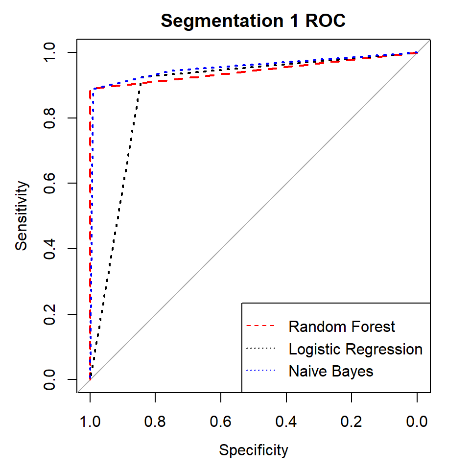

```r
# Plotthe performance of each model
roc.Seg1.rf <- multiclass.roc(test.segOne$userType, as.numeric(customer.segOne.pred))
rs <- roc.Seg1.rf[['rocs']]
plot.roc(rs[[1]], col = "red", lty=2, main = "Segmentation 1 ROC")
roc.Seg1.logit <- multiclass.roc(test.segOne$userType, as.numeric(customer.segOne.lr.pred))
rs <- roc.Seg1.logit[['rocs']]
plot(rs[[1]], col = "black", lty = 3, add = TRUE)
roc.Seg1.nb <- multiclass.roc(test.segOne$userType, as.numeric(customer.segOne.nb.pred))
rs <- roc.Seg1.nb[['rocs']]
plot(rs[[1]], col = "blue", lty = 3, add = TRUE)
legend("bottomright", c("Random Forest","Logistic Regression","Naive Bayes"), col = c("red","black","blue"),
       lty = c(2,3,3), pch = c(-1, -1, -1))
```

#### Segmentation 2: Decisive customers, Tentative customers, Hesitant customers

```r
summary(aggregatedCustomerSums$decisiveratio)
```

```
##    Min. 1st Qu.  Median    Mean 3rd Qu.    Max.
##  0.1667  0.6757  0.7333  0.7455  0.8000  1.0000
```

[output not shown]

```r
# create data labels
decisivelabel <- with(aggregatedCustomerSums, ifelse(decisiveratio >= summary(aggregatedCustomerSums$decisiveratio)[5], 2, ifelse(decisiveratio >= summary(aggregatedCustomerSums$decisiveratio)[2],1,0)))
# merge the created label with selected data
decisive.data <- data.frame(aggregatedCustomerSums[c("pages", "onsite","holiday","gender","lifespan")], decisivelabel = as.factor(decisivelabel))
set.seed(42)
# separate data into train, test data
#randomly get 2/3 data of each label into train data, 1/3 data of each label into test data
hesitant<-subset(decisive.data, decisivelabel == 0)
tentative<-subset(decisive.data, decisivelabel == 1)
decisive<-subset(decisive.data, decisivelabel == 2)
train.h<-hesitant[sample(nrow(hesitant),), ][c(1:1658), ]
test.h<-hesitant[sample(nrow(hesitant),), ][c(1659:2487), ]
train.t<-tentative[sample(nrow(tentative),), ][c(1:3155),]
test.t<-tentative[sample(nrow(tentative),), ][c(3156:4732),]
train.d<-decisive[sample(nrow(decisive),), ][c(1:1854),]
test.d<-decisive[sample(nrow(decisive),), ][c(1854:2781),]
decisive.train<-rbind(train.h, train.t, train.d)
decisive.test<-rbind(test.h, test.t, test.d)
```

##### Predicting using Random Forest

```r
# build the random forest model for classification
customer.rf <- randomForest(decisivelabel~., data=decisive.train, ntree=500, proximity=T)
customer.rf
```

```
##
## Call:
##  randomForest(formula = decisivelabel ~ ., data = decisive.train,      ntree = 500, proximity = T)
##                Type of random forest: classification
##                      Number of trees: 500
## No. of variables tried at each split: 2
##
##         OOB estimate of  error rate: 44.62%
## Confusion matrix:
##     0    1    2 class.error
## 0 427 1013  218   0.7424608
## 1 413 2236  506   0.2912837
## 2 185  640 1029   0.4449838
```

```r
customer.rf.predict <- predict(customer.rf, decisive.test)
customer.rf.table <- table(customer.rf.predict, decisive.test$decisivelabel)
customer.rf.table
```

```
##
## customer.rf.predict    0    1    2
##                   0  633   60   35
##                   1  162 1451  118
##                   2   34   66  775
```

```r
# display the measurement of confusion martixs
classMetrics(customer.rf.table)
```

```
##                 value
## accuracy    0.8575285
## sensitivity 0.8351293
## specificity 0.9584372
## ppv         0.8857143
## npv         0.9377796
```

##### Predicting using KNN

```r
train_control <- trainControl(method = "cv", number = 10)
customer.knn <- train(decisivelabel~., data = decisive.train, trControl = train_control, method = "knn")
customer.knn
```

```
## k-Nearest Neighbors
##
## 6667 samples
##    5 predictor
##    3 classes: '0', '1', '2'
##
## No pre-processing
## Resampling: Cross-Validated (10 fold)
## Summary of sample sizes: 5999, 6001, 6001, 6001, 6002, 5999, ...
## Resampling results across tuning parameters:
##
##   k  Accuracy   Kappa
##   5  0.5245405  0.2348277
##   7  0.5303914  0.2379207
##   9  0.5420946  0.2520983
##
## Accuracy was used to select the optimal model using the largest value.
## The final value used for the model was k = 9.
```

```r
customer.knn.predict <- predict(customer.knn, decisive.test)
customer.knn.table <- table(customer.knn.predict, decisive.test$decisivelabel)
customer.knn.table
```

```
##
## customer.knn.predict    0    1    2
##                    0  242  199  105
##                    1  469 1182  294
##                    2  118  196  529
```

```r
# display the measurement of confusion martixs
classMetrics(customer.knn.table)
```

```
##                 value
## accuracy    0.5857828
## sensitivity 0.5700431
## specificity 0.8694929
## ppv         0.6275208
## npv         0.8398234
```

##### Predicting using Mulrinomial Logistic Regression

```r
decisve.ml <- multinom(decisivelabel ~ . , data = decisive.train)
decisve.ml
```

```
## Call:
## multinom(formula = decisivelabel ~ ., data = decisive.train)
##
## Coefficients:
##   (Intercept)       pages      onsite   holiday   genderM     lifespan
## 1    1.545311 -0.01055008 0.000588137 0.2251431 -1.380147 -0.001176207
## 2    3.808573 -0.02873246 0.001592213 0.4120352 -1.926368 -0.004192695
##
## Residual Deviance: 11695.53
## AIC: 11719.53
```

```r
logit.pred <- decisve.ml %>% predict(decisive.test)
conf.mat.logit<-table(logit.pred, decisive.test$decisivelabel)
conf.mat.logit
```

```
##
## logit.pred    0    1    2
##          0  192  123   55
##          1  502 1199  297
##          2  135  255  576
```

```r
# display the measurement of confusion martixs
classMetrics(conf.mat.logit)
```

```
##                 value
## accuracy    0.5899820
## sensitivity 0.6206897
## specificity 0.8379052
## ppv         0.5962733
## npv         0.8513514
```

##### Predicting using Naive Bayes

```r
decisive.nb <-naiveBayes(decisivelabel ~ . , data = decisive.train, laplace=1)
decisive.nb.pred <- predict(decisive.nb, decisive.test)
conf.mat.nb<-table(decisive.nb.pred, decisive.test$decisivelabel)
conf.mat.nb
```

```
##
## decisive.nb.pred   0   1   2
##                0  47  50  13
##                1 377 889 128
##                2 405 638 787
```

```r
# display the measurement of confusion martixs
classMetrics(conf.mat.nb)
```

```
##                 value
## accuracy    0.5167966
## sensitivity 0.8480603
## specificity 0.5665004
## ppv         0.4300546
## npv         0.9062500
```

##### Predicting using SVM

```r
decisive.svm <-svm(decisivelabel ~ . , data = decisive.train, type = 'C-classification', kernel = 'radial')
decisive.svm.pred <- predict(decisive.svm, decisive.test)
conf.mat.svm<-table(decisive.svm.pred, decisive.test$decisivelabel)
conf.mat.svm
```

```
##
## decisive.svm.pred    0    1    2
##                 0  158   78   62
##                 1  575 1308  376
##                 2   96  191  490
```

```r
# display the measurement of confusion martixs
classMetrics(conf.mat.svm)
```

```
##                 value
## accuracy    0.5866827
## sensitivity 0.5280172
## specificity 0.8807149
## ppv         0.6306306
## npv         0.8287055
```

– Based on the observation of the models of Random Forest, KNN, Mulrinomial Logistic Regression, Naive Bayes and SVM, we can found that Random Forest has the best performance.

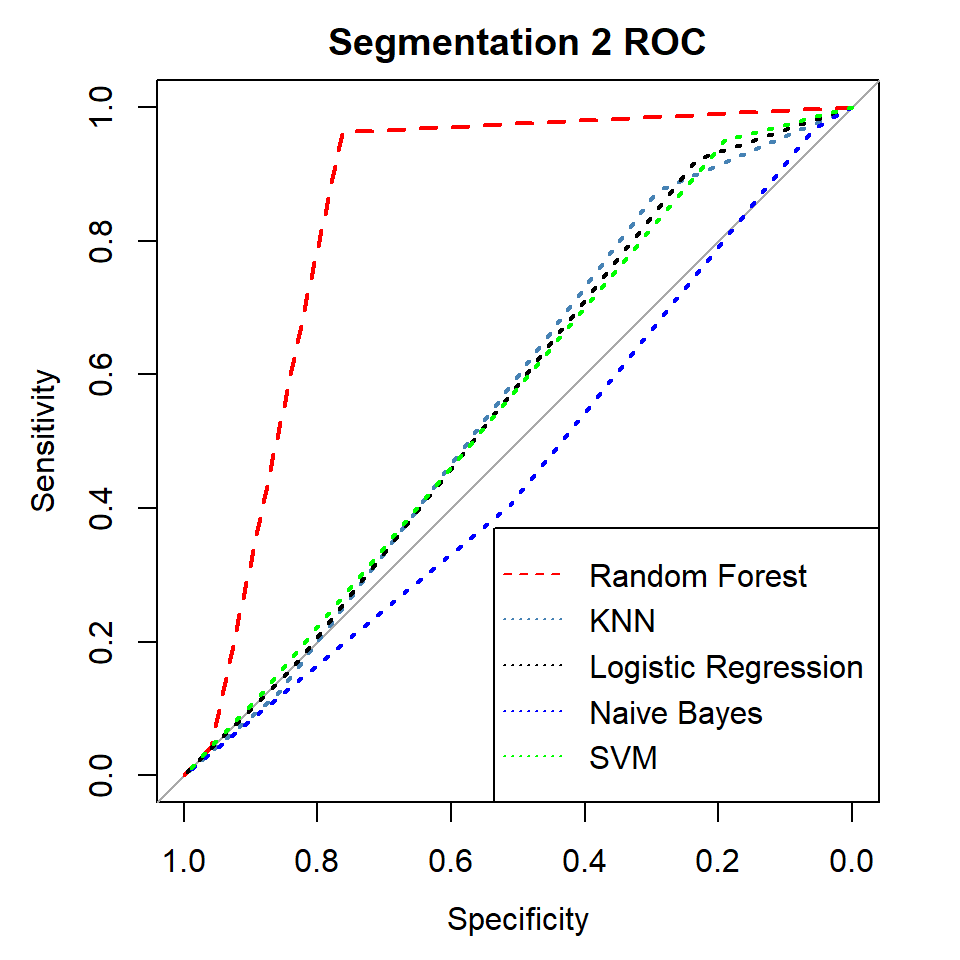

```r
# Plotthe performance of each model
roc.Seg2.rf <- multiclass.roc(decisive.test$decisivelabel, as.numeric(customer.rf.predict))
rs <- roc.Seg2.rf[['rocs']]
plot.roc(rs[[1]], col = "red", lty=2, main = "Segmentation 2 ROC")
roc.Seg2.knn <- multiclass.roc(decisive.test$decisivelabel, as.numeric(customer.knn.predict))
rs <- roc.Seg2.knn[['rocs']]
plot(rs[[1]], col = "steelblue", lty = 3, add = TRUE)
roc.Seg2.logit <- multiclass.roc(decisive.test$decisivelabel, as.numeric(logit.pred))
rs <- roc.Seg2.logit[['rocs']]
plot(rs[[1]], col = "black", lty = 3, add = TRUE)
roc.Seg2.nb <- multiclass.roc(decisive.test$decisivelabel, as.numeric(decisive.nb.pred))
rs <- roc.Seg2.nb[['rocs']]
plot(rs[[1]], col = "blue", lty = 3, add = TRUE)
roc.Seg2.svm <- multiclass.roc(decisive.test$decisivelabel, as.numeric(decisive.svm.pred))
rs <- roc.Seg2.svm[['rocs']]
plot(rs[[1]], col = "green", lty = 3, add = TRUE)
legend("bottomright", c("Random Forest","KNN","Logistic Regression","Naive Bayes","SVM"), col = c("red","steelblue","black","blue","green"),
       lty = c(2,3,3,3,3), pch = c(-1, -1, -1, -1, -1))
```

- The above plot shows the ROC curves for the Random Forest (in red),KNN (in steelblue) Logistic Regression (in black), Naive Bayes (in blue) and SVM (in green). From the graph, we see that only the performance of Random Forest looks acceptable.